# GUV_Analysis_summary

James Foster

2026-05-26

## Details

> **DESCRIPTION**

> Loads the reorganised data from `1Data/colour_dance_reorg.csv`, saved from `GUV_organisedata.R`, and generates plots to show the how dances changed as a function of light stimulus.

> **INPUTS**

> `colour_dance_reorg.csv`, `Edrich1979_brightness-accuracy.csv`

> **OUTPUTS**

> `2Results/phototaxis_modlist.RData`, `2Results/MLE_paired_diffs.csv`, `2Results/MLEdetails_paired_diffs.RData`, `2Results/LRT_paired_diffs.csv`, `2Results/BF_paired_diffs.csv`,

> **REFERENCES**

> Edrich, W., Neumeyer, C. and von Helversen, O. (1979). “Anti-sun orientation” of bees with regard to a field of ultraviolet light. *J. Comp. Physiol.* 134, 151–157.

> Rossel, S. and Wehner, R. (1984). Celestial orientation in bees: the use of spectral cues. *J. Comp. Physiol. A* 155, 605–613.

## Setting up

First load the functions and packages required for this project. These can all be found in `GUV_functions.R`, within the same Github repository.

```r
source('GUV_functions.R')
```

Then load the data that will be used. This includes our own dance data, reorganised by `GUV_organisedata.R` as `colour_dance_reorg.csv`, as well as data from Edrich *et al.* (1979) on the relationship between accuracy (mean vector length), wavelength and intensity. This was manually extracted from Fig. 2 and saved in `"Edrich1979_brightness-accuracy.csv`.

```r
#Dance angle data
cd = read.table(file = '1Data/colour_dance_reorg.csv',
                header = T,
                sep  = ',')
#Accuracy data
ed = read.table(file = '1Data/Edrich1979_brightness-accuracy.csv',
                header = T,
                sep  = ',')
#Inspect each dataset
head(cd)
```

```
##   measured_angle run       date bearing       angle               ID brightn
## 1            270   1 2016.05.31      90  1.57079633 2016.05.31.14.24       l
## 2              5   2 2016.05.31     355 -0.08726646 2016.05.31.14.24       l
## 3             20   3 2016.05.31     340 -0.34906585 2016.05.31.14.24       l
## 4            320   4 2016.05.31      40  0.69813170 2016.05.31.14.24       l
## 5             20   5 2016.05.31     340 -0.34906585 2016.05.31.14.24       l
## 6             35   6 2016.05.31     325 -0.61086524 2016.05.31.14.24       l
##   colour            cet_time   sun_az   sun_el sun_el_rad sun_az_rad
## 1      u 2016-05-31 14:24:00 208.3263 58.81733   1.026556  -2.647205
## 2      u 2016-05-31 14:24:00 208.3263 58.81733   1.026556  -2.647205
## 3      u 2016-05-31 14:24:00 208.3263 58.81733   1.026556  -2.647205
## 4      u 2016-05-31 14:24:00 208.3263 58.81733   1.026556  -2.647205
## 5      u 2016-05-31 14:24:00 208.3263 58.81733   1.026556  -2.647205
## 6      u 2016-05-31 14:24:00 208.3263 58.81733   1.026556  -2.647205
```

```r
head(ed)
```

```
##        xx intensity     nn accuracy wavelength
## 1 -31.208  2.15e+09 13.010     0.14        354
## 2 -20.263  3.69e+09 14.249     0.15        535
## 3  -8.217  6.67e+09 19.135     0.20        354
## 4  -1.342  9.36e+09 15.350     0.16        535
## 5  15.118  2.10e+10 30.769     0.33        354
## 6  24.548  3.35e+10 14.731     0.16        535
```

## Format data

Ensure that each variable has the correct data format for subsequent analysis.

```r
cd = within(cd,
            {
              ID = as.factor(ID) # beedance identifier as a factor
              date = as.factor(date) # date as a factor
              signed_angle = Mod360.180(bearing)  # bearing between -180 and 180
              angle = circular(rad(signed_angle),# bearing between -pi and pi
                               rotation = 'clock') # circular format suppresses later warnings
            }
)
u_id = with(cd, unique(ID)) # unique beedances
length(u_id)#169 beedances
```

```
## [1] 169
```

Identify dances in which all four stimulus conditions were used.

```r
luc = sapply(u_id,
              FUN = IndCond,
              dt = cd)

#Most individuals that made it to bright green
full_ids = u_id[luc == 4]
length(full_ids)#19 individuals
```

```
## [1] 19
```

```r
#extract just those individuals

#find data for full condition individuals
full_cd = subset(cd, ID %in% full_ids)
```

## Check dance length

Ensure that each variable has the correct data format for subsequent analysis.

```r
mruns = aggregate(run ~ ID,
                  data = cd,
                  FUN = max)
summary(mruns$run)
```

```
##    Min. 1st Qu.  Median    Mean 3rd Qu.    Max.
##   14.00   26.00   33.00   36.83   43.00  100.00
```

## Plot the raw dance data

### Plot an example individual to show effect

For example we can look at the dance recorded on 2016.06.20 at 13:17.

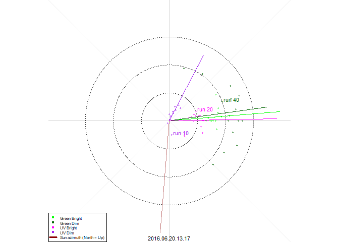

```r
par(pty = 's')
par(mfrow = c(1,1), mar = c(0,0,0,0))
PltDance(ids = '2016.06.20.13.17',
         dtf = cd,
         cx = 0.7)
with(subset(cd, ID %in% '2016.06.20.13.17' & run %in% c(10, 20, 40)),
     {
text(x = run*sin(as.numeric(angle)),
     y = run*cos(as.numeric(angle)),
     labels = paste(' run', run),
     col = c('green', 'darkgreen', 'magenta', 'purple')
            [ifelse(colour %in% 'g',
                    yes = ifelse(brightn %in% 'h', yes = 1, no = 2),
                    no = ifelse(brightn %in% 'h', yes = 3, no = 4))],
     cex = 0.7,
     adj = c(0,0))
     }
)
legend(x = 'bottomleft',
       legend = c('Green Bright',
                  'Green Dim',
                  'UV Bright',
                  'UV Dim',
                  'Sun azimuth (North = Up)'),
       col = c('green',
               'darkgreen',
               'magenta',
               'purple',
               'darkred'),
       pch = c(21,21,21,21,NA),
       lty = c(NA, NA, NA, NA, 1),
       lwd = c(2,2,2,2,3),
       cex = 0.5
       )
```

A plot including all 169 dances can be found at the end of this markdown.

## Accuracy effects

Calculate the mean vectors for each set of waggle-runs under each lighting condition.

```r
#calculate mean vectors
mean_vectors = aggregate(angle~ID*brightn*colour+sun_az+sun_el_rad, # N.B. Including sun azimuth drops some cases without a time stamp
                         data = cd,
                         FUN = rho.circular
)
#correct names
mean_vectors = within(mean_vectors,
                      {mean_vector = angle; rm(angle)} # anlge now indicates a mean vector, not an angle
)
#add kappa
mle_estimates = aggregate(angle~ID*brightn*colour+sun_az+sun_el,
                          data = cd,
                          FUN = MLE_est
)
#Rayleigh tests
rayleigh_tests = aggregate(angle~ID*brightn*colour+sun_az+sun_el,
                          data = cd,
                          FUN = Rayleigh_p
                          )
#add to the summary table and
#calculate inverse softplus kappa
mean_vectors = within(mean_vectors,
                      {
                        mu = deg(mle_estimates$angle[,'mu'])
                        kappa = mle_estimates$angle[,'kappa']
                        iskappa  = inv_softplus(kappa)
                      }
)
#find the full condition individuals
mean_vectors_full = subset(mean_vectors,
                           subset = ID %in% full_ids)
rayleigh_tests_full = subset(rayleigh_tests,
                           subset = ID %in% full_ids)
#check how many dances would count as "oriented"
#all dances
with(rayleigh_tests,
     round(mean(angle <0.05) *100,digits = 2)
     )
```

```
## [1] 88.43
```

```r
#all dances with balanced data
with(rayleigh_tests_full,
     round(mean(angle <0.05) *100,digits = 2)
     )
```

```
## [1] 88.24
```

```r
#bright green (sun spot) dances
with(subset(rayleigh_tests,
            subset = brightn %in% 'h' & colour %in% 'g'),
     round(mean(angle <0.05) *100,digits = 2)
     )
```

```
## [1] 94.44
```

```r
#bright green (sun spot) dances with balanced data
with(subset(rayleigh_tests_full,
            subset = brightn %in% 'h' & colour %in% 'g'),
     round(mean(angle <0.05) *100,digits = 2)
     )
```

```
## [1] 88.24
```

### Effect of brightness on mean vector length

#### Entire dataset

The first thing we notice is that in the low intensity conditions the accuracy is generally lower than for the high intensity conditions.

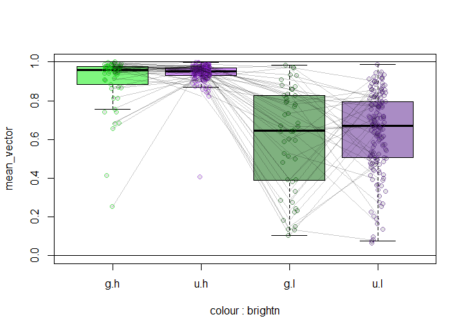

```r
boxplot(mean_vector~colour*brightn,
        data = mean_vectors,
        ylim = c(0,1),
        col = adjustcolor(c('green2',
                            'purple',
                            'darkgreen',
                            'purple4'), alpha.f = 0.5),
        outline = FALSE)
stripchart(mean_vector~colour*brightn,
           data = mean_vectors,
           add = TRUE,
           vertical = TRUE,
           method = 'jitter',
           col = adjustcolor(c('green2',
                               'purple',
                               'darkgreen',
                               'purple4'), alpha.f = 0.5),
           bg = gray(level = 0,
                     alpha = 0.1),
           pch = 21)
#Identify stimuli
stim = apply(X = expand.grid(c = c('g','u'),b = c('h','l')),
             FUN = paste,
             collapse = '',
             MARGIN = 1)
#Plot lines linking dances by the same individual
invisible(
  {
    lapply(X = u_id,
           FUN = Plt_mvec
           )
  })
abline(h = c(0,1))
```

#### Print summary statistics

Use the quantile function to summarise the distribution of mean vectors within each combination of stimulus colour and brightness.

```r
mv_agg =  aggregate(mean_vector~colour*brightn,
           data = mean_vectors,
           FUN = quantile,
           probs = c(0.5, 0.25, 0.75))
rownames(mv_agg) = stim
mv_agg = within(mv_agg, rm(colour, brightn))
mv_agg = t(apply(mv_agg, MARGIN = 1, unlist))
print(mv_agg,
  digits = 3)
```

```
##    mean_vector.50% mean_vector.25% mean_vector.75%
## gh           0.959           0.890           0.977
## uh           0.952           0.930           0.971
## gl           0.646           0.391           0.827
## ul           0.671           0.505           0.795
```

#### Within individuals (balanced cases only)

This effect is even clearer if we look at just the full condition dances.

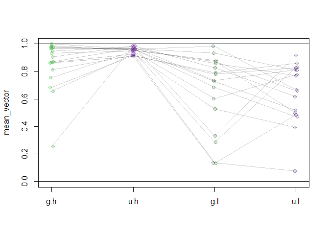

```r
stripchart(mean_vector~colour*brightn,
           data = mean_vectors_full,
           # add = TRUE,
           vertical = TRUE,
           method = 'jitter',
           jitter = 0.02,
           ylim = c(0,1),
           col = adjustcolor(c('green2',
                               'purple',
                               'darkgreen',
                               'purple4'), alpha.f = 0.5),
           bg = gray(level = 0,
                     alpha = 0.1),
           pch = 21)
#Plot lines linking dances by the same individual
invisible(
  {
    lapply(X = full_ids,
           FUN = Plt_mvec
           )
  })
abline(h = c(0,1))
```

### Plot an example individual to show effect

For example we can look at the dance recorded on 2016.06.20 at 13:17.

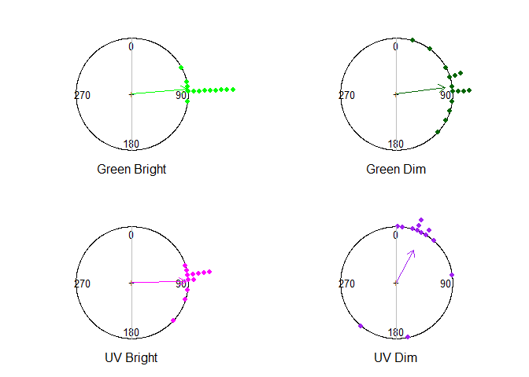

```r
example_subs = subset(x = cd,
                      ID %in% '2016.06.20.13.17')
par(mfrow = c(2,2), mar = c(0,0,0,0))
PCfun(angles = subset(example_subs,
                      subset = colour %in% 'g' & brightn %in% 'h')$bearing,
      col = 'green',
      shrink = 1.5,
      title = 'Green Bright')
PCfun(angles = subset(example_subs,
                      subset = colour %in% 'g' & brightn %in% 'l')$bearing,
      col = 'darkgreen',
      shrink = 1.5,
      title = 'Green Dim')
PCfun(angles = subset(example_subs,
                      subset = colour %in% 'u' & brightn %in% 'h')$bearing,
      col = 'magenta',
      shrink = 1.5,
      title = 'UV Bright')
PCfun(angles = subset(example_subs,
                      subset = colour %in% 'u' & brightn %in% 'l')$bearing,
      col = 'purple',
      shrink = 1.5,
      title = 'UV Dim')
```

### Non-parametric tests on accuracy

Here non-parametric or parametric statistics could be revealing.

```r
#Identify all effects as factors for aligned ranks transform
mean_vectors_full = within(mean_vectors_full,
                           {
                           colour = as.factor(colour)
                           brightn = as.factor(brightn)
                           ID = as.factor(ID)
                           }
                           )
mean_vectors = within(mean_vectors,
                           {
                           colour = as.factor(colour)
                           brightn = as.factor(brightn)
                           ID = as.factor(ID)
                           }
                           )
mv_full_art = art(formula = mean_vector~colour*brightn +
                              (1+colour+brightn|ID),#insufficient DF to estimate interaction
                   data = mean_vectors_full)
sm_mv_full_art = summary(mv_full_art)
```

```
## boundary (singular) fit: see help('isSingular')
## boundary (singular) fit: see help('isSingular')
## boundary (singular) fit: see help('isSingular')
```

```r
#check if rank alignment was successful
message('\nSuccessful rank alignment:\n',
        all(sapply(sm_mv_full_art[11], round) == 0),
        '\n')
```

```
##
## Successful rank alignment:
## TRUE
```

```r
print(anova(mv_full_art), digits = 3)
```

```
## boundary (singular) fit: see help('isSingular')
## boundary (singular) fit: see help('isSingular')
```

```
## Analysis of Variance of Aligned Rank Transformed Data
##
## Table Type: Analysis of Deviance Table (Type III Wald F tests with Kenward-Roger df)
## Model: Mixed Effects (lmer)
## Response: art(mean_vector)
##
##                         F Df Df.res     Pr(>F)
## 1 colour          0.00452  1     16    0.94724
## 2 brightn        56.97631  1     16 1.1689e-06 ***
## 3 colour:brightn  2.99074  1     16    0.10298
## ---
## Signif. codes:   0 '***' 0.001 '**' 0.01 '*' 0.05 '.' 0.1 ' ' 1
```

We can successfully fit an aligned ranks model to compare across individuals. Note that the “boundary” level random effects indicate that individual effects were too small to estimate. In the individual linear models (e.g. `summary(artlm(mv_full_art, "brightn"))$varcor`) there may still be substantial individual differences. The primary effect appears to be that of brightness, but there may also be effects of interest in the post-hoc contrasts.

```r
cn_mv_full_art = sapply(X = c('brightn', 'colour', 'colour:brightn'),
                        FUN = ART_extract,
                        mod = mv_full_art,
                        adjust = 'sidak')
```

```
## NOTE: Results may be misleading due to involvement in interactions
```

```
## boundary (singular) fit: see help('isSingular')
```

```
## NOTE: Results may be misleading due to involvement in interactions
```

```r
print(cn_mv_full_art)
```

```
## $brightn
##  contrast estimate   SE df t.ratio p.value
##  h - l        25.5 3.37 16   7.548  <.0001
##
## Results are averaged over the levels of: colour
## Degrees-of-freedom method: kenward-roger
##
## $colour
##  contrast estimate   SE df t.ratio p.value
##  g - u      -0.353 5.25 16  -0.067  0.9472
##
## Results are averaged over the levels of: brightn
## Degrees-of-freedom method: kenward-roger
##
## $`colour:brightn`
##  contrast  estimate   SE   df t.ratio p.value
##  g,h - g,l    17.71 3.51 28.3   5.038  0.0001
##  g,h - u,h   -11.35 4.84 22.2  -2.347  0.1579
##  g,h - u,l    22.00 6.29 16.0   3.497  0.0178
##  g,l - u,h   -29.06 4.02 16.0  -7.231  <.0001
##  g,l - u,l     4.29 4.84 22.2   0.888  0.9455
##  u,h - u,l    33.35 3.51 28.3   9.490  <.0001
##
## Degrees-of-freedom method: kenward-roger
## P value adjustment: sidak method for 6 tests
```

The post-hoc tests indicate a large difference between bright and dim conditions, as expected, but very little evidence for differences between colours. The interactions (for which there was low support in the overall model) reflect the pattern we expect, that all bright conditions have higher accuracy than all dim conditions, and that while the two dim conditions have similar accuracy, the bright UV bright condition may be slightly more accurate the bright green condition (p = 0.158).

### Parametric beta-distributed model of accuracy

To investigate this with greater statistical power we would need an appropriate parametric model for bounded variables. One approach is to use the beta distribution, which is defined between (but not at) 0 and 1.

#### Beta model for accuracy

```r
### Maximal formula with all random effects ---------------------
#set up model formula with indiv effects on light type
frm_bmod_maxRE = bf(mean_vector~brightn*colour + # light types affect accuracy
                            (1 + brightn*colour|ID), # each individual is more or less oriented
              phi ~ brightn*colour + # light types affect variance in accuracy
                      (1 + brightn*colour|ID), # some individuals vary more in accuracy than others
              family = brms::Beta())

#suggest prior values
pr_mu_Intercept = list(dist = 'normal',
             mu = 0,
             sd = 1)#deconstrain to beat divergences?
pr_phi_Intercept = list(dist = 'normal',
             mu = 1,
             sd = 1)
pr_mu_b = list(dist = 'normal',
             mu = 0,
             sd = 1)#deconstrain to beat divergences?
pr_phi_b = list(dist = 'normal',
             mu = 0,
             sd = 1)
pr_mu_sd_Intercept = list(dist = 'student_t',
             df = 3,
             mu = 0,
             sd = 0.1)#constrain to beat divergences?
pr_phi_sd_Intercept = list(dist = 'student_t',
                 df = 3,
                 mu = 0,
                 sd = 0.1)#constrain to beat divergences?
pr_mu_sd = list(dist = 'student_t',
             df = 3,
             mu = 0,
             sd = 0.1)#constrain to beat divergences?
pr_phi_sd = list(dist = 'student_t',
                 df = 3,
                 mu = 0,
                 sd = 0.1)#constrain to beat divergences?

### Assign priors --------------------------------------------------------

#set priors on:
# - all coefficients to a normal(0,1) = 95% probability of values 0.12–0.87
# - all grouping paramters to a student_t(df = 3, mu = 0, sigma = 2.5) = values < 5.88
# - all other parameters (?) to a normal(0,10)= 95% probability of values 0–1 +- 1e-7

pr_expression = expression({
  prior = sapply(class,
                 switch,
                 Intercept = with(pr_mu_Intercept,
                          {paste0(dist,'(',mu,',',sd,')')}),
                 #the general prior for coefficients (should centre on 0)
                 b = with(pr_mu_b,
                          {paste0(dist,'(',mu,',',sd,')')}),
                 #the general prior for standard deviations (should be long-tailed)
                 sd =  with(pr_mu_sd,
                           {paste0(dist,'(',df,',',mu,',',sd,')')}),
                 cor = 'lkj(1)', # The only supported prior for correlation matrices is the 'lkj' prior
                 'normal(0,1)' # with this many params need more informative priors
      )
  #special priors
    #mu sd intercept
  prior[dpar %in% '' & class %in% 'sd' & coef %in% ''] =
    with(pr_mu_sd_Intercept,
                          {paste0(dist,'(',df,',',mu,',',sd,')')})
  #phi b
  prior[dpar %in% 'phi' & class %in% 'b'] =
    with(pr_phi_b,
                          {paste0(dist,'(',mu,',',sd,')')})
  #phi intercept
  prior[dpar %in% 'phi' & class %in% 'b' & coef %in% ''] =
    with(pr_phi_Intercept,
                          {paste0(dist,'(',mu,',',sd,')')})
  #phi sd
  prior[dpar %in% 'phi' & class %in% 'sd'] =
    with(pr_phi_sd,
                          {paste0(dist,'(',df,',',mu,',',sd,')')})
  #phi sd intercept
  prior[dpar %in% 'phi' & class %in% 'sd' & coef %in% ''] =
    with(pr_phi_sd_Intercept,
                          {paste0(dist,'(',df,',',mu,',',sd,')')})
}
)

#model with all random effects
priors_bmod_mxRE = within(get_prior(formula = frm_bmod_maxRE,
                                    data = mean_vectors_full),
                          expr = eval(pr_expression))
#remove excess priors generated by get_prior but not used by brms
priors_bmod_mxRE = subset(priors_bmod_mxRE, !(coef %in% ''))
print(priors_bmod_mxRE)#all parameters are accounted for
```

```
##               prior class             coef group resp dpar nlpar lb ub tag
##         normal(0,1)     b         brightnl
##         normal(0,1)     b brightnl:colouru
##         normal(0,1)     b          colouru
##  student_t(3,0,0.1)    sd         brightnl    ID
##  student_t(3,0,0.1)    sd brightnl:colouru    ID
##  student_t(3,0,0.1)    sd          colouru    ID
##  student_t(3,0,0.1)    sd        Intercept    ID
##         normal(0,1)     b         brightnl             phi
##         normal(0,1)     b brightnl:colouru             phi
##         normal(0,1)     b          colouru             phi
##  student_t(3,0,0.1)    sd         brightnl    ID       phi
##  student_t(3,0,0.1)    sd brightnl:colouru    ID       phi
##  student_t(3,0,0.1)    sd          colouru    ID       phi
##  student_t(3,0,0.1)    sd        Intercept    ID       phi
##   source
##  default
##  default
##  default
##  default
##  default
##  default
##  default
##  default
##  default
##  default
##  default
##  default
##  default
##  default
```

```r
## Run the models --------------------------------------------------------
system.time( #takes about 2 minutes
  {
md_beta = brm(formula = frm_bmod_maxRE,
                 prior = priors_bmod_mxRE,
                 data = within(mean_vectors_full,
                               {
                               mean_vector = (mean_vector * (length(mean_vector) - 1) + 0.5) / length(mean_vector)
                               }
                               ),
                 family = Beta(link = 'logit',
                               link_phi = 'log'),
                 iter = 2e3, # only small number necessary
                 control = list( adapt_delta = 0.99 ), # divergences are hard to beat, so set very high
                 cores = 4,
                 backend = 'cmdstanr',
                 silent = 2, #don't print lots of iteration information
                 refresh = 0
)
  }
)
```

```
##    user  system elapsed
##    3.91    0.50   87.87
```

```r
#some divergent transitions, but rhat and ESS look good
rh_beta = rhat(md_beta)
sm_beta = summary(md_beta)
print(summary(rh_beta), digits= 4)#all ≤1.01
```

```
##    Min. 1st Qu.  Median    Mean 3rd Qu.    Max.
##  0.9994  1.0003  1.0009  1.0012  1.0017  1.0048
```

```r
print(sm_beta$fixed[, c(1, 3:4)], digits = 3)
```

```
##                      Estimate l-95% CI u-95% CI
## Intercept               1.774    1.303   2.2218
## phi_Intercept           1.812    1.203   2.3751
## brightnl               -1.169   -1.787  -0.5245
## colouru                 0.961    0.425   1.4764
## brightnl:colouru       -0.944   -1.659  -0.2101
## phi_brightnl           -0.755   -1.557   0.0683
## phi_colouru             2.022    0.972   3.0021
## phi_brightnl:colouru   -1.132   -2.314   0.2044
```

Extract the model’s predictions and compare with the original data.

```
## Ignoring unknown labels:
## • fill : "NA"
## • colour : "NA"
## Ignoring unknown labels:
## • fill : "NA"
## • colour : "NA"
```

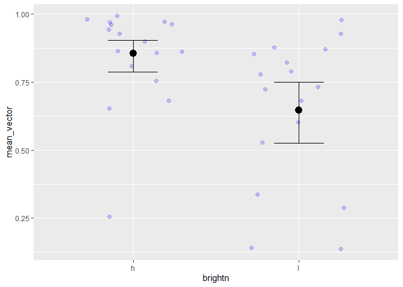

```
## Ignoring unknown labels:
## • fill : "NA"
## • colour : "NA"
## Ignoring unknown labels:
## • fill : "NA"
## • colour : "NA"
```

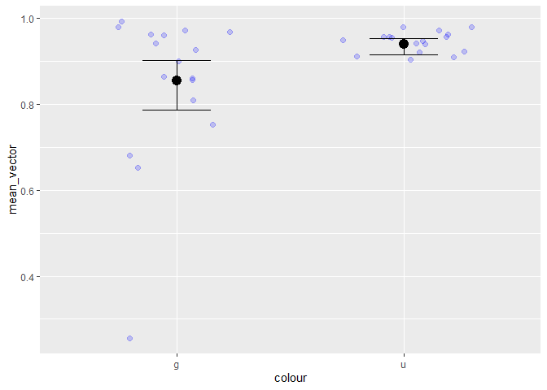

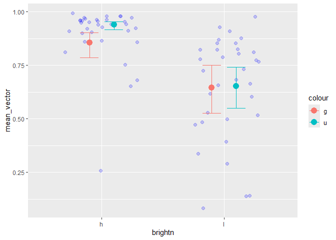

```r
# Extract model predictions -----------------------------------------------
beta_cond_eff = conditional_effects(md_beta)
#Plot including individual data points
plot(x = beta_cond_eff,
     points = TRUE,
     point_args = list(width = 0.3,
                       col = adjustcolor('blue',
                                         alpha.f = 0.2),
                       width = 0.3
                       ),
     ylim = c(0,1),
     ask = FALSE
    )
```

This seems to suggest that dances were more accurate in the bright UV condition, which the aligned-ranks test was sceptical of. We can quantify this difference by extracting and comparing the parameter estimates from each (post-warmup) iteration of the model.

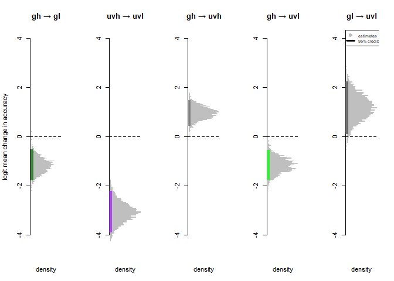

```r
draws_beta = prepare_predictions(md_beta,
                                 re_formula = NA)#just population level effects
#for the average vector length
draws_mu = draws_beta$dpars$mu$fe$b
#for variance in vector length
draws_phi = draws_beta$dpars$phi$fe$b
#N.B. Could also just calculate predictions, then subtract
contr_mu = with(data.frame(draws_mu),
                {
                  data.frame(
                    #bright green -> dim green = low brightness effect
                    gh_gl = b_brightnl,
                    #bright UV -> dim UV = dim + UVdim - UV effect
                    uvh_uvl = b_brightnl + `b_brightnl.colouru` - b_colouru,
                    #bright green -> bright UV = UV effect
                    gh_uvh = b_colouru,
                    #bright green -> dim UV = UV + dim + UVdim
                    gh_uvl = b_brightnl + b_colouru + `b_brightnl.colouru`,
                    #dim green -> dim UV = UV effect + UVdim - dim effect
                    gl_uvl = b_colouru + `b_brightnl.colouru` - b_brightnl
                  )
                }
                )
#On the original scale
contr_rho = with(data.frame(draws_mu),
                {
                  data.frame(
                    #bright green -> dim green = low brightness effect
                    gh_gl = plogis(b_Intercept + b_brightnl) -
                              plogis(b_Intercept),
                    #bright UV -> dim UV = dim + UVdim - UV effect
                    uvh_uvl = plogis(b_Intercept + b_brightnl + `b_brightnl.colouru`) -
                              plogis(b_Intercept + b_colouru),
                    #bright green -> bright UV = UV effect
                    gh_uvh = plogis(b_Intercept + b_colouru) -
                              plogis(b_Intercept),
                    #bright green -> dim UV = UV + dim + UVdim
                    gh_uvl = plogis(b_Intercept + b_brightnl +
                                      b_colouru + `b_brightnl.colouru`)-
                              plogis(b_Intercept),
                    #dim green -> dim UV = UV effect + UVdim - dim effect
                    gl_uvl = plogis(b_Intercept + b_colouru +
                                      `b_brightnl.colouru`) -
                              plogis(b_Intercept + b_brightnl)
                  )
                }
                )

contr_phi = with(data.frame(draws_phi),
                {
                  data.frame(
                    #bright green -> dim green = low brightness effect
                    gh_gl = b_phi_brightnl,
                    #bright UV -> dim UV = dim + UVdim - UV effect
                    uvh_uvl = b_phi_brightnl + `b_phi_brightnl.colouru` - b_phi_colouru,
                    #bright green -> bright UV = UV effect
                    gh_uvh = b_phi_colouru,
                    #bright green -> dim UV = UV + dim + UVdim
                    gh_uvl = b_phi_brightnl + b_phi_colouru + b_phi_brightnl.colouru,
                    #dim green -> dim UV = UV effect + UVdim - dim effect
                    gl_uvl = b_phi_colouru + `b_phi_brightnl.colouru` - b_phi_brightnl
                  )
                }
                )
contr_all = cbind(contr_mu, contr_phi)
quant_all = apply(X = contr_all,
                  MARGIN = 2,
                  FUN = quantile,
                  probs = c(0,0.5,1)+c(1,0,-1)*(0.05)/2
                  )
quant_mu = apply(X = contr_mu,
                  MARGIN = 2,
                  FUN = quantile,
                  probs = c(0,0.5,1)+c(1,0,-1)*(0.05)/2
                  )
quant_rho = apply(X = contr_rho,
                  MARGIN = 2,
                  FUN = quantile,
                  probs = c(0,0.5,1)+c(1,0,-1)*(0.05)/2
                  )
quant_phi = apply(X = contr_phi,
                  MARGIN = 2,
                  FUN = quantile,
                  probs = c(0,0.5,1)+c(1,0,-1)*(0.05)/2
                  )
par(mfrow = c(1, length(contr_mu)))
for(ct in 1:length(contr_mu) )
{
  VertHist(data = contr_mu[,ct],
           main = gsub(pattern = '_',
                              replacement = ' → ',
                              x = names(contr_mu)[ct]),
           axes = FALSE,
           col = gray(0.75),
           ylim = c(-1, 1)*4,
           ylab = if(ct ==1){'logit mean change in accuracy'}else{''}
           )
  axis(2)

  abline(h = 0,
       lty = 2)
with(data.frame(t(quant_mu[,ct])),
     {
      arrows(x0 = 0,
             y0 = X2.5.,
             y1 = X97.5.,
             length = 0,
             angle = 90,
             lwd = 5,
             col = adjustcolor(c('darkgreen',
                            'purple',
                            'gray40',
                            'green',
                            'gray25'
                            ), alpha = 0.7)[ct],
             lend = 'butt'
             )
     }
)
}

legend(x = 'topleft',
       legend = c('estimates',
                  '95% credible interval'),
       pch = c(20, NA),
       lty = c(NA, 1),
       lwd = c(5, 3),
       col = c('gray', 'black'),
       cex = 0.7
       )
```

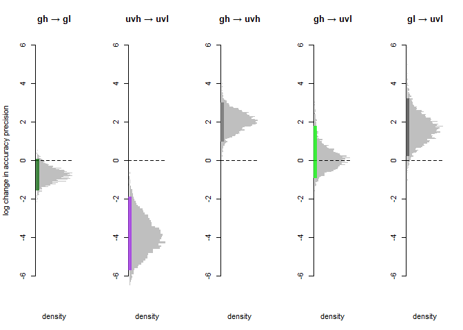

```r
par(mfrow = c(1, length(contr_phi)))
for(ct in 1:length(contr_phi) )
{
  VertHist(data = contr_phi[,ct],
           main = gsub(pattern = '_',
                              replacement = ' → ',
                              x = names(contr_phi)[ct]),
           axes = FALSE,
           col = gray(0.75),
           ylim = c(-1, 1)*6,
           ylab = if(ct ==1){'log change in accuracy precision'}else{''}
           )
  axis(2)

  abline(h = 0,
       lty = 2)
with(data.frame(t(quant_phi[,ct])),
     {
      arrows(x0 = 0,
             y0 = X2.5.,
             y1 = X97.5.,
             length = 0,
             angle = 90,
             lwd = 5,
             col = adjustcolor(c('darkgreen',
                            'purple',
                            'gray40',
                            'green',
                            'gray25'
                            ), alpha = 0.7)[ct],
             lend = 'butt'
             )
     }
)
}
```

```r
#can also calculate these with emmeans
em_beta = emmeans(object = md_beta,
                  specs = ~brightn*colour)
ct_beta_mu = contrast(object = em_beta,
                   specs = ~brightn*colour,
                   method = 'pairwise',
                   side = c(1,-1,1,-1,-1,1)
                   )
print(ct_beta_mu, digits = 3)
```

```
##  contrast  estimate lower.HPD upper.HPD
##  h g - l g   1.1648     0.547      1.81
##  h g - h u  -0.9635    -1.509     -0.46
##  h g - l u   1.1502     0.555      1.77
##  l g - h u  -2.1301    -2.720     -1.54
##  l g - l u  -0.0117    -0.615      0.57
##  h u - l u   2.1141     1.575      2.59
##
## Point estimate displayed: median
## Results are given on the log odds ratio (not the response) scale.
## HPD interval probability: 0.95
```

```r
#collect and estimate p values from samples
empirical.p = function(x, tails = 2){ifelse(test = median(x)>0,
                                            yes = mean(x<0)*tails,
                                            no = mean(x>0)*tails)
}

p_beta_mu = apply(X = contr_mu, MARGIN = 2, FUN = empirical.p, tails = 2)
p_beta_phi = apply(X = contr_phi, MARGIN = 2, FUN = empirical.p, tails = 2)
beta_all_res = data.frame(rho_lower = quant_rho[1,],
                          rho_median = quant_rho[2,],
                          rho_upper = quant_rho[3,],
                          mu_lower = quant_mu[1,],
                          mu_median = quant_mu[2,],
                          mu_upper = quant_mu[3,],
                          p_mu = p_beta_mu,
                          p_mu_adj = p.adjust(p = p_beta_mu,
                                              method = 'BH'),
                          phi_lower = quant_phi[1,],
                          phi_median = quant_phi[2,],
                          phi_upper = quant_phi[3,],
                          p_phi = p_beta_phi,
                          p_phi_adj = p.adjust(p = p_beta_phi,
                                              method = 'BH')
                          )
print(beta_all_res[,c(2,5,7,10)], digits = 3)
```

```
##         rho_median mu_median   p_mu phi_median
## gh_gl      -0.2066    -1.165 0.0020    -0.7592
## uvh_uvl    -0.5228    -3.078 0.0000    -3.9487
## gh_uvh      0.0838     0.964 0.0005     2.0306
## gh_uvl     -0.2025    -1.150 0.0005     0.0758
## gl_uvl      0.2087     1.181 0.0290     1.6318
```

#### Investigate effect of sun elevation

```r
#set up model formula with indiv effects on light type
frm_elemod_maxRE = bf(mean_vector~ cos(sun_el_rad) + # accuracy is affected by projection distortion at high elevations following a cosine law
                            (1 |ID), # each individual is more or less oriented
              phi ~ cos(sun_el_rad) + # accuracy is affected by projection distortion at high elevations following a cosine law
                      (1 |ID), # some individuals vary more in accuracy than others
              family = brms::Beta())

#suggest prior values
pr_mu_Intercept = list(dist = 'normal',
             mu = 0,
             sd = 1)#deconstrain to beat divergences?
pr_phi_Intercept = list(dist = 'normal',
             mu = 1,
             sd = 1)
pr_mu_b = list(dist = 'normal',
             mu = 0,
             sd = 1)#deconstrain to beat divergences?
pr_phi_b = list(dist = 'normal',
             mu = 0,
             sd = 1)
pr_mu_sd_Intercept = list(dist = 'student_t',
             df = 3,
             mu = 0,
             sd = 0.1)#constrain to beat divergences?
pr_phi_sd_Intercept = list(dist = 'student_t',
                 df = 3,
                 mu = 0,
                 sd = 0.1)#constrain to beat divergences?
pr_mu_sd = list(dist = 'student_t',
             df = 3,
             mu = 0,
             sd = 0.1)#constrain to beat divergences?
pr_phi_sd = list(dist = 'student_t',
                 df = 3,
                 mu = 0,
                 sd = 0.1)#constrain to beat divergences?

### Assign priors --------------------------------------------------------

#set priors on:
# - all coefficients to a normal(0,1) = 95% probability of values 0.12–0.87
# - all grouping paramters to a student_t(df = 3, mu = 0, sigma = 2.5) = values < 5.88
# - all other parameters (?) to a normal(0,10)= 95% probability of values 0–1 +- 1e-7

pr_expression = expression({
  prior = sapply(class,
                 switch,
                 Intercept = with(pr_mu_Intercept,
                          {paste0(dist,'(',mu,',',sd,')')}),
                 #the general prior for coefficients (should centre on 0)
                 b = with(pr_mu_b,
                          {paste0(dist,'(',mu,',',sd,')')}),
                 #the general prior for standard deviations (should be long-tailed)
                 sd =  with(pr_mu_sd,
                           {paste0(dist,'(',df,',',mu,',',sd,')')}),
                 cor = 'lkj(1)', # The only supported prior for correlation matrices is the 'lkj' prior
                 'normal(0,1)' # with this many params need more informative priors
      )
  #special priors
    #mu sd intercept
  prior[dpar %in% '' & class %in% 'sd' & coef %in% ''] =
    with(pr_mu_sd_Intercept,
                          {paste0(dist,'(',df,',',mu,',',sd,')')})
  #phi b
  prior[dpar %in% 'phi' & class %in% 'b'] =
    with(pr_phi_b,
                          {paste0(dist,'(',mu,',',sd,')')})
  #phi intercept
  prior[dpar %in% 'phi' & class %in% 'b' & coef %in% ''] =
    with(pr_phi_Intercept,
                          {paste0(dist,'(',mu,',',sd,')')})
  #phi sd
  prior[dpar %in% 'phi' & class %in% 'sd'] =
    with(pr_phi_sd,
                          {paste0(dist,'(',df,',',mu,',',sd,')')})
  #phi sd intercept
  prior[dpar %in% 'phi' & class %in% 'sd' & coef %in% ''] =
    with(pr_phi_sd_Intercept,
                          {paste0(dist,'(',df,',',mu,',',sd,')')})
}
)

#model with all random effects
priors_elemod_mxRE = within(get_prior(formula = frm_elemod_maxRE,
                                    data = mean_vectors_full),
                          expr = eval(pr_expression))
#remove additional priors added by get_prior but not used by brms
priors_elemod_mxRE  = subset(priors_elemod_mxRE, !(coef %in% ''))
print(priors_elemod_mxRE)#all parameters are accounted for
```

```
##               prior class          coef group resp dpar nlpar lb ub tag  source
##         normal(0,1)     b cossun_el_rad                                 default
##  student_t(3,0,0.1)    sd     Intercept    ID                           default
##         normal(0,1)     b cossun_el_rad             phi                 default
##  student_t(3,0,0.1)    sd     Intercept    ID       phi                 default
```

```r
system.time( #takes about 2 minutes
  {
md_ele = brm(formula = frm_elemod_maxRE,
                 prior = priors_elemod_mxRE,
                 data = within(mean_vectors_full,
                               {
                               mean_vector = (mean_vector * (length(mean_vector) - 1) + 0.5) / length(mean_vector)

                               }
                               ),
                 family = Beta(link = 'logit',
                               link_phi = 'log'),
                 iter = 2e3, # only small number necessary
                 control = list( adapt_delta = 0.99 ), # divergences are hard to beat, so set very high
                 cores = 4,
                 backend = 'cmdstanr',
                 silent = 2, #don't print lots of iteration information
                 refresh = 0
)
  }
)
```

```
##    user  system elapsed
##    0.64    0.37   32.56
```

```r
#too many divergent transitions, check chains
rh_ele = rhat(md_ele)
sm_ele = summary(md_ele)
print(summary(rh_ele), digits= 4)#all ≤1.01
```

```
##    Min. 1st Qu.  Median    Mean 3rd Qu.    Max.
##  0.9997  1.0002  1.0007  1.0009  1.0013  1.0039
```

```r
print(sm_ele$fixed[, c(1, 3:4)], digits = 3)
```

```
##                   Estimate l-95% CI u-95% CI
## Intercept            1.618    0.670    2.537
## phi_Intercept        1.364    0.246    2.471
## cossun_el_rad       -0.786   -2.246    0.638
## phi_cossun_el_rad   -0.351   -2.001    1.311
```

Extract the model’s predictions and compare with the original data.

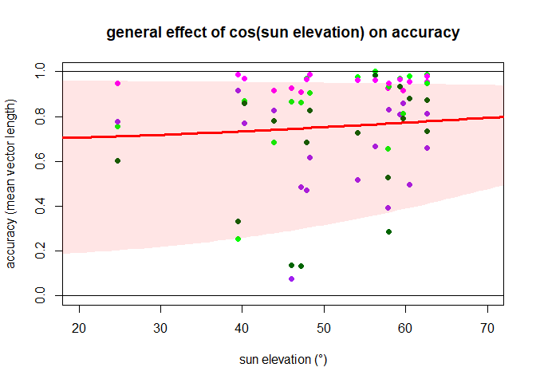

```r
fx_ele = sm_ele$fixed[, c(1, 3:4)]
with(mean_vectors_full,
     {
     plot(x = as.numeric(deg(sun_el_rad)),
          y = mean_vector,
          xlab = 'sun elevation (°)',
          ylab = 'accuracy (mean vector length)',
          main = 'general effect of cos(sun elevation) on accuracy',
          xlim = c(20,70),
          ylim = c(0,1),
          pch = 19,
          col = sapply(X = paste0(brightn, colour),
                       FUN = switch,
                       hg = 'green',
                       lg = 'darkgreen',
                       hu = 'magenta',
                       lu = 'purple'
                       )
         )
     }
     )
abline(h = c(0,1))
polygon(x = c(0:85, 85:0),
        y = plogis(
          c(fx_ele$`u-95% CI`[1] + fx_ele$`u-95% CI`[3]*
                        cos(rad(0:85)),
              rev( fx_ele$`l-95% CI`[1] + fx_ele$`l-95% CI`[3]*
                        cos(rad(0:85)) )
              )
          ),
        col = adjustcolor('red', alpha.f = 0.1),
        border = NA)
lines(x = 0:85,
      y = plogis(
                  fx_ele$Estimate[1] + fx_ele$Estimate[3]*
                        cos(rad(0:85))
                  ),
      col = 'red',
      lwd = 3)
```

```r
loo_beta = loo(md_beta)
loo_ele = loo(md_ele)
loo_compare(loo_beta, loo_ele)
```

```
##         elpd_diff se_diff
## md_beta   0.0       0.0
## md_ele  -23.1       7.1
```

### Comparison with Edrich *et al.* (1979)

How does this compare with previous experiments in which a light spot (2.3°) was presented through bandpass filters and ND filters to produce different intensities? In that data, there was a clear sigmoidal relationship between intensity and accuracy (mean vector length). They mention that the particular relationship with light intensity was variable, but that the relative relationships remained constant, so we may also observe the same relationship but shifted.

> Unfortunately, the scatter of the dance directions as a function of light intensity proved to be unstable over long periods of time; the absolute values changed from day to day. However, these changes were such that curves for adjacent wavelengths were shifted in parallel - the relative sensitivities remained constant. — Edrich et al. (1979), p154

#### Plot raw data from Edrich *et al.* (1979) Fig. 2

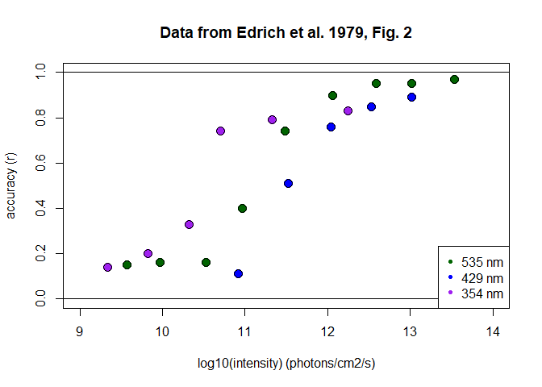

```r
with(ed,
     {
     plot(x = log10(intensity),
          y = accuracy,
          xlim = c(9,14),
          ylim = c(0,1),
          main = 'Data from Edrich et al. 1979, Fig. 2',
            xlab = 'log10(intensity) (photons/cm2/s)',
            ylab = 'accuracy (r)',
          pch = 21,
          cex = 1.5,
          col = 'black',
          bg = sapply(paste(wavelength),
                       FUN = switch,
                       `354` = 'purple',
                       `429` = 'blue',
                       `535` = 'darkgreen',
                       'red')
          )
     abline(h = c(0,1))
     }
     )

legend(x = 'bottomright',
       legend = paste(sort(unique(ed$wavelength),
                     decreasing = TRUE), 'nm'),
       col = c('darkgreen','blue', 'purple'),
       pch = c(20, 20, 20))
```

This is best modelled with a nonlinear (psychometric model) following the beta distribution (for variables bounded between zero and one).

#### Reorganise data

```r
ed = within(ed,
            {
              logit_accuracy = qlogis(accuracy)
              log10_intensity = log10(intensity)
              colour = sapply(paste(wavelength),
                              FUN = switch,
                              `354` = 'UV',
                              `429` = 'blue',
                              `535` = '0green',
                              NA)
            }
            )
```

#### Fit psychometric curves

For each light stimulus, fit a sigmoid curve bounded between baseline accuracy (shared across stimuli) and maximum accuracy (`1 - lapses`). Inflection point and 80%-rise-region width vary between stimuli, maximising posterior probability for a beta distribution in `(0,1)`. To do this, we first define a nonlinear formula in `brms`.

```r
#set up model fit
formula_beta = bf(
  formula = accuracy ~
    inv_logit(LogitBase) + (1 - inv_logit(LogitLapse) - inv_logit(LogitBase) ) *#curve region
    inv_logit( 4.39*(log10_intensity - Inflex) / exp(LogWidth) ) , #inflection-width curve
  # for each of these parameters, we can set up a separate formula
  # that describes how to predict them from the data
  #Base rate of correct choices: "
  LogitBase ~ 1, #Base rate of correct choices: "~ 1" gives the instruction "estimate the mean across all data"
  #Lapse rate on a log(odds) scale:
  LogitLapse ~ colour, #this is similar to the formula in our LMM example
  #inflection point of the initial curve:
  Inflex ~ colour, #N.B. this is similar to the intercept, so it does not include effects of stimulus level
  #log 80% width of the curve:
  LogWidth ~ colour, #N.B. this is similar to the slope, so all of its effects depend on stimulus level
  family = Beta(link = "identity", link_phi = 'log'),
  nl = TRUE)#the joint distribution for these parameters is undefined, and therefore the parameters themselves are "nonlinear"
```

Since this is a nonlinear model (there are terms both inside and outside the logistic transform) it is important to establish prior distributions for all parameters. These ensure that parameter estimates explore credible ranges during fitting. The baseline is expected to be around $r = 0.27$, while the maximum accuracy should be around $r = 0.95$, and their estimates should not converge (that would flatten the curve, or reverse its direction). The inflection points are expected around $10^{11}$ photons cm$^{-2}$ s$^{-1}$, with a rise-region width of $10^{3}$ photons cm$^{-2}$ s$^{-1}$. All colour effects may vary by a few orders of magnitude.

```r
#set up priors
prior_beta = get_prior(formula = formula_beta,
                     data = ed)
#set the prior distribution
prior_beta = within(prior_beta,
                  { prior[
                    class %in% 'b' & #just the fixed effects
                      nlpar %in% 'LogitBase' &
                      coef %in% 'Intercept'
                  ] = 'normal(-1,1)' #a normal distribution centred on plogis(-1) = 0.27
                  })
#this prior is automatically bounded between 0 and 1,
#Lapse rate priors ---------------------------------------------------
prior_beta = within(prior_beta,
                  { prior[
                    class %in% 'b' & #just the fixed effects
                      nlpar %in% 'LogitLapse' &
                      coef %in% 'Intercept'
                  ] = 'normal(-3,2)' #a normal distribution centred on -3
                  })

#for all other fixed effects on lapse rate, we'll suggest values around 0 (no effect)
prior_beta = within(prior_beta,
                  { prior[
                    class %in% 'b' & #just the fixed effects
                      nlpar %in% 'LogitLapse' &
                      coef %in% 'colourblue'
                  ] = 'normal(0,2)' #a normal distribution:mean 0, sd 3
                  })
prior_beta = within(prior_beta,
                  { prior[
                    class %in% 'b' & #just the fixed effects
                      nlpar %in% 'LogitLapse' &
                      coef %in% 'colourUV'
                  ] = 'normal(0,2)' #a normal distribution:mean 0, sd 3
                  })

#Inflection point priors ---------------------------------------------
prior_beta = within(prior_beta,
                  { prior[
                    class %in% 'b' & #just the fixed effects
                      nlpar %in% 'Inflex' &
                      coef %in% 'Intercept'
                  ] = 'normal(11,2)' #a normal distribution:mean 11, sd 2
                  })
#for all coefficients, we'll suggest values around 0 (no effect)
prior_beta = within(prior_beta,
                  { prior[
                    class %in% 'b' & #just the fixed effects
                      nlpar %in% 'Inflex' &
                      coef %in% 'colourblue'
                  ] = 'normal(0,2)' #a normal distribution:mean 0, sd 2
                  })

prior_beta = within(prior_beta,
                  { prior[
                    class %in% 'b' & #just the fixed effects
                      nlpar %in% 'Inflex' &
                      coef %in% 'colourUV'
                  ] = 'normal(0,2)' #a normal distribution:mean 0, sd 2
                  })

#Rise region width priors --------------------------------------------
prior_beta = within(prior_beta,
                  { prior[
                    class %in% 'b' & #just the fixed effects
                      nlpar %in% 'LogWidth' &
                      coef %in% 'Intercept'
                  ] = 'normal(1,2)' #a normal distribution:mean 1, sd 3
                  })
#for all coefficients, we'll suggest values around 0 (no effect)
prior_beta = within(prior_beta,
                  { prior[
                    class %in% 'b' & #just the fixed effects
                      nlpar %in% 'LogWidth' &
                      coef %in% 'colourblue'
                  ] = 'normal(0,2)' #a normal distribution:mean 0, sd 3
                  })
prior_beta = within(prior_beta,
                  { prior[
                    class %in% 'b' & #just the fixed effects
                      nlpar %in% 'LogWidth' &
                      coef %in% 'colourUV'
                  ] = 'normal(0,2)' #a normal distribution:mean 0, sd 3
                  })
```

Fit a psychometric model to the data using the nonlinear formula and specified prior distributions. `4000` iterations on `4` chains takes less than one minute.

```r
#takes less than 1 minute
#parameters for the brms runs
wup = 2000
sam = 2000
refr = 0
system.time(
  {
    beta_fit = brm( formula = formula_beta, # using our nonlinear formula
                     data = ed, # our data
                     prior = prior_beta, # our priors
                     iter = wup+sam, # long run for 4000 iterations
                     chains = 4, # 4 chains in parallel
                     cores = 4, # on 4 CPUs
                     refresh = refr,
                     silent = 0, # don't echo chain progress
                     control = list(adapt_delta = 0.95), #finer sampling
                     backend = 'cmdstanr') # use cmdstanr (other compilers broken)
  }
)
```

```
## Running MCMC with 4 parallel chains...
```

```
## Chain 3 Informational Message: The current Metropolis proposal is about to be rejected because of the following issue:
```

[output not shown]

```
## Chain 3 If this warning occurs sporadically, such as for highly constrained variable types like covariance matrices, then the sampler is fine,
```

```
## Chain 3 but if this warning occurs often then your model may be either severely ill-conditioned or misspecified.
```

```
## Chain 3
```

```
## Chain 1 finished in 4.4 seconds.
## Chain 3 finished in 4.5 seconds.
## Chain 2 finished in 5.0 seconds.
## Chain 4 finished in 5.0 seconds.
##
## All 4 chains finished successfully.
## Mean chain execution time: 4.7 seconds.
## Total execution time: 5.1 seconds.
```

```
##    user  system elapsed
##    0.77    0.44   25.76
```

#### Plot and compare data from Edrich and Kühn.

Summarise the data from full cases in the Kühn data using quantiles (minimum, 25%, median, 75% and maximum).

```r
#Examine quantiles
meanQ = aggregate(mean_vector ~ colour*brightn,
                  data = mean_vectors_full,
                  FUN = quantile)
#Extract different quantiles as separate columns in a data frame
meanQ = data.frame(cbind(meanQ[1:2], meanQ$mean_vector) )
#Rename
names(meanQ) = c('colour', 'brightn', paste0('q',0:4))
#Subset by condition
gh_meanQ = subset(meanQ, colour %in% 'g' & brightn %in% 'h')
gl_meanQ = subset(meanQ, colour %in% 'g' & brightn %in% 'l')
uh_meanQ = subset(meanQ, colour %in% 'u' & brightn %in% 'h')
ul_meanQ = subset(meanQ, colour %in% 'u' & brightn %in% 'l')
```

Extract the model predictions by summarising parameter estimates from the sampling phases of all chains. To identify specific combinations of parameter values, use the `conditional_effects` function, which organises all simultaneous estimates into a data frame.

```r
# #N.B. for plotting we will need to also define "inv_logit" in our the R environment
inv_logit = inv_logit_scaled # this can be found in brms, but with an additional specifier

#summary of parameter estimates
full_sm_beta = summary(beta_fit,
                  robust = TRUE)#use the median estimate
#Extract fixed effects estimates
full_fix_beta = full_sm_beta$fixed
#extract rownames
full_fix_rn_beta = rownames(full_fix_beta)

# stimulus levels to add to the dataset to be able to measure this effect.
full_estimates_beta = full_fix_beta$Estimate
names(full_estimates_beta) = full_fix_rn_beta

# to predict all effects, we can use the 'posterior_epred' method
#by default 100 predictions per continuous variable (but fewer for their interactions)
#This takes <2 seconds
system.time(
  {
    full_cond_beta =brms::conditional_effects(beta_fit,
                                         method = 'posterior_epred', # posterior epred not working
                                         cores =  parallel::detectCores()-1,
                                         effects = c('log10_intensity:colour'),
                                         plot = FALSE
    )
  }
)
```

```
##    user  system elapsed
##    2.48    0.19    2.65
```

```r
#extract predictions
pred_data_beta = full_cond_beta$`log10_intensity:colour`

#Green light curve
g_curve =
with(data.frame(t(full_estimates_beta)),
     {
       list(Base = plogis(LogitBase_Intercept),
            Maxima = 1- plogis(LogitLapse_Intercept),
            Inflection = Inflex_Intercept,
            Width = exp(LogWidth_Intercept)
       )
     }
)

#UV light curve
u_curve =
with(data.frame(t(full_estimates_beta)),
     {
       list(Base = plogis(LogitBase_Intercept),
            Maxima = 1- plogis(LogitLapse_Intercept + LogitLapse_colourUV),
            Inflection = Inflex_Intercept + Inflex_colourUV,
            Width = exp(LogWidth_Intercept + LogWidth_colourUV)
       )
     }
)
```

Plot the raw data alongside the predictions for the data from Edrich *et al*., (1979) and a boxplot summary of the data data from Kühn (2017).

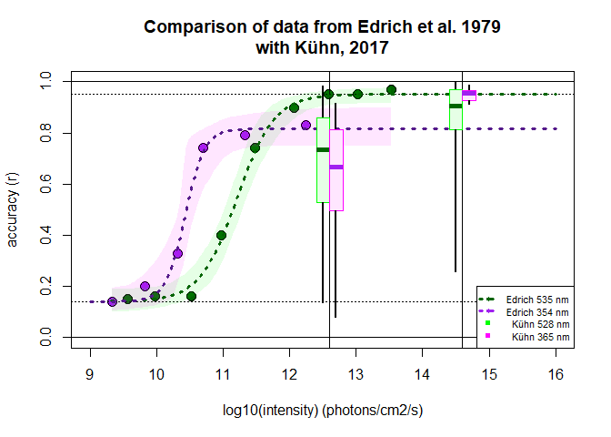

```r
#Prepare a sequence for plotting
xxl = seq(from = 9, to = 16,
          length.out = 1e3)

#plot only the stimulus types also used by Kühn.
ed_ug = subset(ed, wavelength != 429)

#plot each stimulus type
with(ed_ug,
     {
       plot(x = log10_intensity,
            y = accuracy,
            main =
'Comparison of data from Edrich et al. 1979
with Kühn, 2017',
            xlab = 'log10(intensity) (photons/cm2/s)',
            ylab = 'accuracy (r)',
            ylim = c(0,1),
            xlim = c(9,16),
            pch = 21,
            cex = 1.5,
            col = 'black',
            bg = sapply(paste(wavelength),
                        FUN = switch,
                        `354` = 'purple',
                        `429` = 'blue',
                        `535` = 'darkgreen',
                        'red')
       )
       abline(h = c(0,1))
       abline(v = log10(4*c(1e12,1e14)) )
     }
)
#Add the estimated range of the curve for the green stimulus
with(data.frame(t(full_estimates_beta)),
     {
  abline(h = c(0,1,
               plogis(LogitBase_Intercept),
               1- plogis(LogitLapse_Intercept) ),
         lty = c(1,1,3,3)
         )
     }
)

#plot total 95% prediction intervals
with(subset(pred_data_beta, colour == '0green'),
     {
       polygon(x = c(sort(log10_intensity), rev(sort(log10_intensity))),
               y = c(lower__[order(log10_intensity)],
                     rev(upper__[order(log10_intensity)])
               ),
               col = adjustcolor('green', alpha.f = 25/256),
               border = NA,
               lwd = 0.1
       )
     }
)
with(subset(pred_data_beta, colour == 'UV'),
     {
       polygon(x = c(sort(log10_intensity), rev(sort(log10_intensity))),
               y = c(lower__[order(log10_intensity)],
                     rev(upper__[order(log10_intensity)])
               ),
               col = adjustcolor('magenta', alpha.f = 25/256),
               border = NA,
               lwd = 0.1
       )
     }
)

#plot the median prediction lines
with(g_curve,
     lines(x = xxl,
           y = Base + (Maxima  - Base) *
             plogis(4.39*(xxl - Inflection)/Width),
           col = 'darkgreen',
           lwd = 3,
           lty = 3)
)
with(u_curve,
     lines(x = xxl,
           y = Base + (Maxima  - Base) *
             plogis(4.39*(xxl - Inflection)/Width),
           col = 'purple4',
           lwd = 3,
           lty = 3)
)

#plot observed data from Kühn as boxplots showing the quartiles, median and total range.
#Green High intensity
QBox(quant = subset(meanQ, colour %in% 'g' & brightn %in% 'h'),
     x = log10(4e14),
     offset = -0.1,
     cols = c('green', 'darkgreen')
    )

#Green Low intensity
QBox(quant = subset(meanQ, colour %in% 'g' & brightn %in% 'l'),
     x = log10(4e12),
     offset = -0.1,
     cols = c('green', 'darkgreen')
    )

#UV High intensity
QBox(quant = subset(meanQ, colour %in% 'u' & brightn %in% 'h'),
     x = log10(4e14),
     offset = 0.1,
     cols = c('magenta', 'purple')
    )

#UV Low intensity
QBox(quant = subset(meanQ, colour %in% 'u' & brightn %in% 'l'),
     x = log10(4e12),
     offset = 0.1,
     cols = c('magenta', 'purple')
    )

legend(x = 'bottomright',
       legend = c(
                   paste('Edrich',
                        sort(unique(ed_ug$wavelength),
                           decreasing = TRUE), 'nm'),
                   paste('  Kühn', c(528, 365), 'nm' )
       ),
       col = c('darkgreen', 'purple', 'green', 'magenta'),
       pch = c(20, 20, 15, 15),
       lty = c(3,3,NA, NA),
       lwd = 3,
       cex = 0.7)
```

It would be difficult to explain the orientation accuracy for the high intensity ($4*10^{14}$) UV stimulus from the accuracy curve for Edrich’s UV data, but it would fit well with the maximum accuracy observed for green light. In Edrich’s study, the green light was interpreted as the sun (dances at correct angle between sun and feeder), whereas the UV light was interpreted as a patch of sky near the anti-sun. In Kühn’s data the stimuli were larger (assuming $10°$ across) than Edrich’s ($2.3°$), which may have resulted in them being perceived as dimmer (left shift in this graph).

# Sun compass orientation

Since most dances were at least somewhat oriented ($r>0.5$) we can assume that the mean angles of these dances typically align with an intended dance direction. If most dances are for the same geographic location, we should observe dances as the same fixed angle to the stimulus, interpreted either as the sun or the anti-sun.

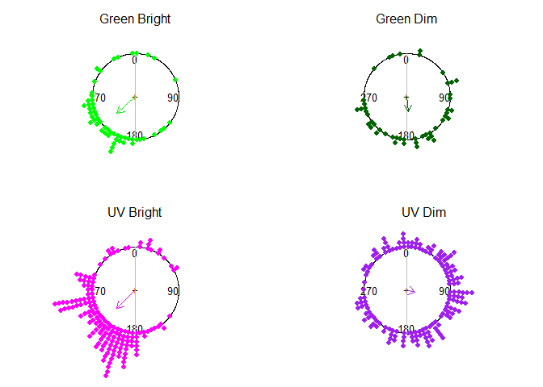

```r
sun_diff_gh = sapply(X = u_id,
                    FUN = SunDiff,
                    dt = mean_vectors,
                    cl = 'g',
                    br = 'h')
sun_diff_gl = sapply(X = u_id,
                    FUN = SunDiff,
                    dt = mean_vectors,
                    cl = 'g',
                    br = 'l')
sun_diff_uh = sapply(X = u_id,
                    FUN = SunDiff,
                    dt = mean_vectors,
                    cl = 'u',
                    br = 'h')
sun_diff_ul = sapply(X = u_id,
                    FUN = SunDiff,
                    dt = mean_vectors,
                    cl = 'u',
                    br = 'l')


par(mfrow = c(2,2), mar = c(0,0,0,0))
PCfun(angles = unlist(sun_diff_gh),
      col = 'green',
      shrink = 2.0,
      side = 3,
      title = 'Green Bright')
PCfun(angles = unlist(sun_diff_gl),
      col = 'darkgreen',
      shrink = 2.0,
      side = 3,
      title = 'Green Dim')
PCfun(angles = unlist(sun_diff_uh),
      col = 'magenta',
      shrink = 2.0,
      side = 3,
      title = 'UV Bright')
PCfun(angles = unlist(sun_diff_ul),
      col = 'purple',
      shrink = 2.0,
      side = 3,
      title = '           UV Dim')
```

For the bright stimuli the dances generally indicate South, but with a very wide range. (or possibly clusters to the South-West and South-East). For the dim stimuli there is less of a clear pattern, particularly for UV dim.

We can also restrict this analysis to just the dances with all conditions.

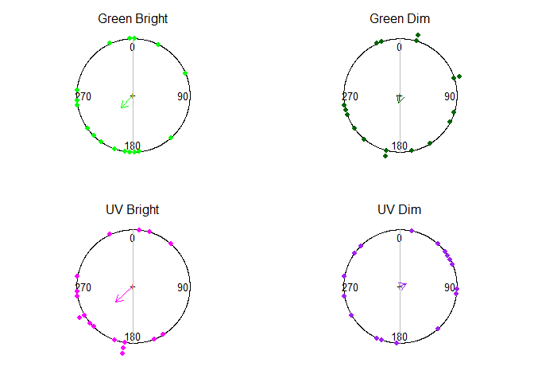

```r
full_sun_diff_gh = sapply(X = full_ids,
                    FUN = SunDiff,
                    dt = mean_vectors,
                    cl = 'g',
                    br = 'h')
full_sun_diff_gl = sapply(X = full_ids,
                    FUN = SunDiff,
                    dt = mean_vectors,
                    cl = 'g',
                    br = 'l')
full_sun_diff_uh = sapply(X = full_ids,
                    FUN = SunDiff,
                    dt = mean_vectors,
                    cl = 'u',
                    br = 'h')
full_sun_diff_ul = sapply(X = full_ids,
                    FUN = SunDiff,
                    dt = mean_vectors,
                    cl = 'u',
                    br = 'l')


par(mfrow = c(2,2), mar = c(0,0,0,0))
PCfun(angles = unlist(full_sun_diff_gh),
      col = 'green',
      shrink = 1.5,
      side = 3,
      title = 'Green Bright')
PCfun(angles = unlist(full_sun_diff_gl),
      col = 'darkgreen',
      shrink = 1.5,
      side = 3,
      title = 'Green Dim')
PCfun(angles = unlist(full_sun_diff_uh),
      col = 'magenta',
      shrink = 1.5,
      side = 3,
      title = 'UV Bright')
PCfun(angles = unlist(full_sun_diff_ul),
      col = 'purple',
      shrink = 1.5,
      side = 3,
      title = 'UV Dim')
```

# Inspect dance angles relative to the stimulus

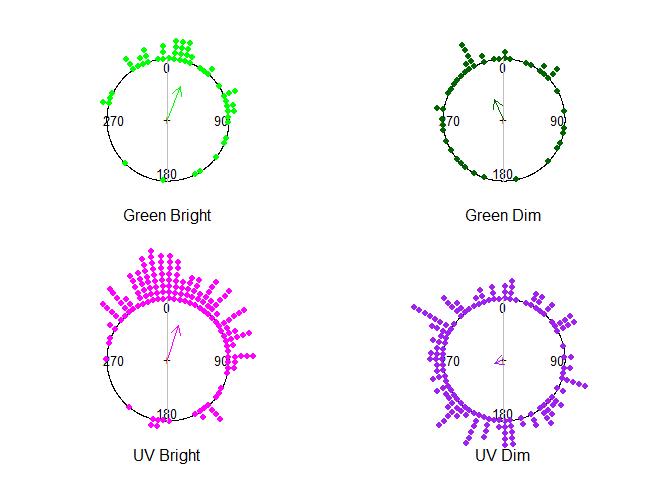

```r
par(mfrow = c(2,2), mar = c(0,0,0,0))
PCfun(angles = subset(mean_vectors,
                      subset = colour %in% 'g' & brightn %in% 'h')$mu,
      col = 'green',
      shrink = 1.75,
      title = 'Green Bright')
PCfun(angles = subset(mean_vectors,
                      subset = colour %in% 'g' & brightn %in% 'l')$mu,
      col = 'darkgreen',
      shrink = 1.75,
      title = 'Green Dim')
PCfun(angles = subset(mean_vectors,
                      subset = colour %in% 'u' & brightn %in% 'h')$mu,
      col = 'magenta',
      shrink = 1.75,
      title = 'UV Bright')
PCfun(angles = subset(mean_vectors,
                      subset = colour %in% 'u' & brightn %in% 'l')$mu,
      col = 'purple',
      shrink = 1.75,
      title = 'UV Dim')
```

```r
cd_sd = aggregate(circular(mu, units = 'degrees')~colour*brightn,
                  FUN = sd.circular,
                  data = mean_vectors)
cd_rho = aggregate(circular(mu, units = 'degrees')~colour*brightn,
                  FUN = rho.circular,
                  data = mean_vectors)
names(cd_sd)[3] = 'circular_sd'
names(cd_rho)[3] = 'rho'
cd_desc = merge(cd_sd, cd_rho)
cd_desc = within(cd_desc,
                 {sd_degrees = deg(circular_sd)})
print(cd_desc,digits = 2)
```

```
##   colour brightn circular_sd  rho sd_degrees
## 1      g       h         1.0 0.58         60
## 2      g       l         1.4 0.36         82
## 3      u       h         1.0 0.59         59
## 4      u       l         1.9 0.16        110
```

## Compare Sun-Spot & Phototaxis Hypotheses

It is likely that a plurality of dancers had visited locations in the Marburg Botanic Gardens, perhaps in the centre of the main growing area (50°48’03.3”N 8°48’24.1”E). The hive is at 50°48’22.7”N 8°48’40.8”E. That would give the following bearing:

```r
# Define the coordinates

hive_coords  =  c(longitude  = 8.811333,
                 latitude = 50.806306)

#the 150m circle intersecting with the nearest edge
garden_coords = list(left =
                       c(longitude  = 8.808956,
                         latitude = 50.805509),
                     centre =
                       c(longitude  = 8.810290,
                         latitude = 50.805565),
                     right =
                       c(longitude  = 8.810110,
                         latitude = 50.804854)
                     )

#find the bearing from the hive
garden_bearing = sapply(garden_coords,
                        FUN = bearing,
                        p1 = hive_coords
                        )
#standard bearing
print(garden_bearing %% 360)
```

```
##     left   centre    right
## 242.1153 221.7301 208.0902
```

```r
garden_bearing_rad = rad(as.numeric(garden_bearing[2]))
```

```r
#save and load models instead of running them each time
load_model = FALSE
# Custom family for "unwrap" von Mises distribution
unwrap_von_mises = custom_family(
  "unwrap_von_mises", dpars = c("mu", "kappa"),
  links = c('identity',#brms cannot accept custom link functions, do via nl instead
            "softplus"),
  lb = c(-pi, 0),
  ub = c(pi, NA),
  type = "real"
)

## Stan variables


### Functions

stan_unwrap_fun = stanvar(scode = "
  real unwrap_von_mises_lpdf(real y, real mu, real kappa) {
    return von_mises_lpdf(y | mod_circular(mu), kappa);
  }
  real unwrap_von_mises_rng(real mu, real kappa) {
    return von_mises_rng( mod_circular(mu) , kappa);
  }
  real unwrap_von_mises_vect_lpdf(vector y, real mu, real kappa) {
    real tmp = 0;
    for(i in 1:size(y))
    {
    tmp = tmp + unwrap_von_mises_lpdf(y[i] | mu, kappa);
    }
      return tmp;
  }
",
                          block = 'functions') +
  stanvar(scode = "
  real mod_circular(real y) {
    return fmod(y + pi(), 2*pi()) - pi();
  }

  real inv_mod_circular(real y) {
    return mod_circular(y);
  }
",
          block = 'functions')

### Parameters

#concentration of random effects on fixed effect on mean angle
kappamu_param = stanvar(scode = "
real kappamu;
                           ",
                            block = "parameters") +
  stanvar(scode = "
real kappa_mu = log1p_exp(kappamu);
          ",
          block = 'genquant')


stanvars_unwrap = stan_unwrap_fun + kappamu_param

#subset to just gh data
cd_gh = subset(cd,
               subset = brightn %in% 'h' &
                         colour %in% 'g' &
                         !is.na(sun_az_rad) # for fair comparison only include cases where the sun azimuth is known
               )

dt_photo = within(cd_gh,
            {
              BR = brightn
              CL = colour
              DT = date
              RN = run
              sunangle = angle + sun_az_rad
            }
)

dt_sun = within(dt_photo,
                {bgangle = sunangle - garden_bearing_rad}
                )


# Model formulae
#model assuming mean direction at 0°, with individual biases
formula_photo = bf(
  formula = angle ~ mu,
            nlf(mu ~ mu0 + mui),
            mu0 ~ 0, # fixed effects intercept == 0
            mui ~ 0 + ID,
            kappa ~ 1 + (1|ID),
  family = unwrap_von_mises,#mod mu, kappa via the softplus
  nl = TRUE)#to accept user-defined extra parameters (mui) we need to treat the formula as nonlinear

#model allowing any angle
formula_nophoto = bf(
  formula = angle ~ mu,
            nlf(mu ~ mu0 + mui),
            mu0 ~ 1, # fixed effects intercept estimated
            mui ~ 0 + ID,
            kappa ~ 1 + (1|ID),
  family = unwrap_von_mises,#mod mu, kappa via the softplus
  nl = TRUE)#to accept user-defined extra parameters (mui) we need to treat the formula as nonlinear

formula_sunspot = bf(
  formula = bgangle ~ mu,
            nlf(mu ~ mu0 + mui),
            mu0 ~ 0, # fixed effects intercept estimated
            mui ~ 0 + ID,
            kappa ~ 1 + (1|ID),
  family = unwrap_von_mises,#mod mu, kappa via the softplus
  nl = TRUE)#to accept user-defined extra parameters (mui) we need to treat the formula as nonlinear

formula_nosunspot = bf(
  formula = bgangle ~ mu,
            nlf(mu ~ mu0 + mui),
            mu0 ~ 1, # fixed effects intercept estimated
            mui ~ 0 + ID,
            kappa ~ 1 + (1|ID),
  family = unwrap_von_mises,#mod mu, kappa via the softplus
  nl = TRUE)#to accept user-defined extra parameters (mui) we need to treat the formula as nonlinear

# Priors
#priors for mu
pr_photo =
  set_prior(paste("target +=",
                  'unwrap_von_mises_vect_lpdf(b_mui | 0, log1p_exp(kappamu))',
                  '+ normal_lpdf(b_mui | 0, 2*pi())'# additional prior to keep estimates from walking around the circle # not necessary with shrinkage prior
  ),
  check = FALSE) +
  set_prior("target += lognormal_lpdf(log1p_exp(kappamu) | log(15), 0.6)", #shrinkage prior differences should be large
            check = FALSE) +
    prior(normal(3.0,3.0), class = Intercept, dpar = 'kappa') + # bias to oriented
  prior(student_t(3, 0, 3.0), class = sd, dpar = 'kappa')  # weak bias no differences

#for models with a mean we also need an extra parameter
pr_nophoto = pr_photo +
  prior(unwrap_von_mises(0,1e-16), class = b,  nlpar = 'mu0', coef = 'Intercept')

#parameters for the brms runs
wup = 1000 #number of warmup iterations used to tune the sampler
sam = 1000 #number of iterations to sample
refr = 0 #print progress every n iterations
siln = 2#print only very important messages

#these are pretty slow! About 7 minutes in total
if(load_model)
{ load(file = '2Results/phototaxis_modlist.RData')
}else
  {
  cglm_photo = brm(formula = formula_photo,
                  data = dt_photo,
                  prior = pr_photo,
                  stanvars = stanvars_unwrap,
                  warmup = wup,#may be necessary
                  iter = wup+sam, #doesn't take a lot of runs
                  chains = 4, # 4 chains in parallel
                  cores = 4, # on 4 CPUs
                  # control = list(adapt_delta = 0.90),
                 refresh = refr, # echo chain progress every n iterations
                 silent = siln, # echo some Stan messages
                  save_pars = save_pars(all = TRUE), # <--- Crucial for moment matching
                 backend = 'cmdstanr')

  cglm_nophoto = brm(formula = formula_nophoto,
                  data = dt_photo,
                  prior = pr_nophoto,
                  stanvars = stanvars_unwrap,
                  warmup = wup,#may be necessary
                  iter = wup+sam, #doesn't take a lot of runs
                  chains = 4, # 4 chains in parallel
                  cores = 4, # on 4 CPUs
                  # control = list(adapt_delta = 0.90),
                 refresh = refr, # echo chain progress every n iterations
                 silent = siln, # echo some Stan messages
                  save_pars = save_pars(all = TRUE), # <--- Crucial for moment matching
                 backend = 'cmdstanr')

  cglm_sunspot = brm(formula = formula_sunspot,
                  data = dt_sun,
                  prior = pr_photo,#different response, same predictors
                  stanvars = stanvars_unwrap,
                  warmup = wup,#may be necessary
                  iter = wup+sam, #doesn't take a lot of runs
                  chains = 4, # 4 chains in parallel
                  cores = 4, # on 4 CPUs
                  control = list(adapt_delta = 0.90),
                 refresh = refr, # echo chain progress every n iterations
                 silent = siln, # echo some Stan messages
                  save_pars = save_pars(all = TRUE), # <--- Crucial for moment matching
                 backend = 'cmdstanr')

  cglm_nosunspot = brm(formula = formula_nosunspot,
                  data = dt_sun,
                  prior = pr_nophoto,#different response, same predictors
                  stanvars = stanvars_unwrap,
                  warmup = wup,#may be necessary
                  iter = wup+sam, #doesn't take a lot of runs
                  chains = 4, # 4 chains in parallel
                  cores = 4, # on 4 CPUs
                  control = list(adapt_delta = 0.90),
                 refresh = refr, # echo chain progress every n iterations
                 silent = siln, # echo some Stan messages
                  save_pars = save_pars(all = TRUE), # <--- Crucial for moment matching
                 backend = 'cmdstanr')
#combine into a single list
modlist = list(phototaxis = cglm_photo,
            no_phototaxis = cglm_nophoto,
            sunspot = cglm_sunspot,
            no_sunspot = cglm_nosunspot)
  }
#summarise
suppressWarnings({ #for circular models rhats may be smaller than they appear
sm_modlist = lapply(X = modlist,
       FUN = summary)
})
Sm_only = function(x,
                   type = 'fixed',
                   var = 'kappa_Intercept')
{
  x[[type]][var,]
}

#average kappa
print(lapply(X = sm_modlist, Sm_only), digits = 3 )
```

```
## $phototaxis
##                 Estimate Est.Error l-95% CI u-95% CI Rhat Bulk_ESS Tail_ESS
## kappa_Intercept     8.95      1.01     7.05       11    1     1450     2468
##
## $no_phototaxis
##                 Estimate Est.Error l-95% CI u-95% CI Rhat Bulk_ESS Tail_ESS
## kappa_Intercept     8.91      1.03        7       11    1     1087     1612
##
## $sunspot
##                 Estimate Est.Error l-95% CI u-95% CI Rhat Bulk_ESS Tail_ESS
## kappa_Intercept     8.89      1.01     6.98     10.9    1     1433     2041
##
## $no_sunspot
##                 Estimate Est.Error l-95% CI u-95% CI Rhat Bulk_ESS Tail_ESS
## kappa_Intercept     8.92      1.04     6.95     11.1    1     1215     1906
```

```r
#across individuals kappa
print(lapply(X = sm_modlist, Sm_only, type = 'spec_pars', var = 'kappa_mu'), digits = 3 )
```

```
## $phototaxis
##          Estimate Est.Error l-95% CI u-95% CI Rhat Bulk_ESS Tail_ESS
## kappa_mu     1.74     0.289     1.22     2.34    1     4889     2826
##
## $no_phototaxis
##          Estimate Est.Error l-95% CI u-95% CI Rhat Bulk_ESS Tail_ESS
## kappa_mu     1.85     0.307     1.29     2.49    1     3754     2297
##
## $sunspot
##          Estimate Est.Error l-95% CI u-95% CI Rhat Bulk_ESS Tail_ESS
## kappa_mu     1.91     0.313     1.33     2.55    1     3527     3163
##
## $no_sunspot
##          Estimate Est.Error l-95% CI u-95% CI Rhat Bulk_ESS Tail_ESS
## kappa_mu     1.88     0.317      1.3     2.55    1     3109     2580
```

```r
#check population means
lapply(X = modlist[c(2,4)],
       FUN = UnwrapRhats,
       variable = '^b_mu0')
```

```
## $no_phototaxis
## b_mu0_Intercept
##         1.00855
##
## $no_sunspot
## b_mu0_Intercept
##         1.00234
```

```r
#Summarise Rhats
lapply(X = modlist,
       FUN = SumUwRhats)
```

```
## $phototaxis
##    Min. 1st Qu.  Median    Mean 3rd Qu.    Max.
##  0.9998  0.9999  1.0001  1.0003  1.0004  1.0033
##
## $no_phototaxis
##    Min. 1st Qu.  Median    Mean 3rd Qu.    Max.
##  0.9998  1.0000  1.0005  1.0017  1.0030  1.0097
##
## $sunspot
##    Min. 1st Qu.  Median    Mean 3rd Qu.    Max.
##  0.9998  0.9999  1.0001  1.0003  1.0006  1.0034
##
## $no_sunspot
##    Min. 1st Qu.  Median    Mean 3rd Qu.    Max.
##  0.9998  1.0000  1.0003  1.0007  1.0011  1.0068
```

```r
#calculate loo
if(!load_model)
{
modlist = lapply(modlist,
       FUN = add_criterion,
       'loo',
       moment_match = TRUE)

save(modlist,
     file = '2Results/phototaxis_modlist.RData')
}
```

```
## Recompiling the model with 'rstan'
```

```
## Recompilation done
```

```
## Recompiling the model with 'rstan'
## Recompilation done
```

```
## Recompiling the model with 'rstan'
## Recompilation done
```

```
## Recompiling the model with 'rstan'
## Recompilation done
```

```r
#compare the phototaxis models
with(modlist, loo_compare(phototaxis, no_phototaxis))
```

```
##               elpd_diff se_diff
## phototaxis     0.0       0.0
## no_phototaxis -0.4       0.8
```

```r
#compare the sun-spot orientation models
with(modlist, loo_compare(sunspot, no_sunspot))
```

```
##            elpd_diff se_diff
## sunspot     0.0       0.0
## no_sunspot -1.0       0.7
```

```r
#compare LOO IC
LooIC = function(lmod)
{
  loo(lmod)$estimates['looic', 'Estimate']
}

modLIC = lapply(X = modlist,
       FUN = LooIC)
print(sort(unlist(modLIC)), digits = 1)
```

```
##       sunspot    phototaxis no_phototaxis    no_sunspot
##           642           643           644           644
```

There is very little separation between our different hypotheses here, suggesting each would do well to explain the data. We can also look at the specific predictions to see how well each hypothesis matches.

### Hypothesis test

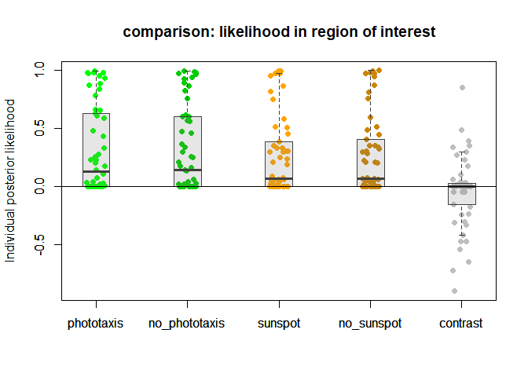

```r
#since all models are similarly credible, what about the hypotheses?
#check if the sector surrounding the expected direction is equally full

#for each individual, calculate the likelihood of foraging in the expected region

PostROPE = function(id, rope, drs, mu = 'b_mu0_Intercept')
{
  mu = if(!is.na(mu)){with(drs, get(mu))}else{0}
  dr_id = with(drs,
               {
               mod_circular(
                 mu +
                  get(paste0('b_mui_ID', id)
                            )
               )
               }
              )
  #centre both
  circ_rope = circular(rope, template = 'none')
  circ_dr = circular(dr_id, template = 'none')
  mean_rope = mean.circular(circ_rope)
  rope_ctr = as.numeric(mod_circular(circ_rope - mean_rope))
  dr_ctr = as.numeric(mod_circular(dr_id - mean_rope))
  postp = mean( rope_ctr[1] < dr_id &
                dr_id  < rope_ctr[2])
  return(postp)
}

photo_id = unique(dt_photo$ID)

#width of sector
rope_width = abs(mod_circular(rad(diff(garden_bearing[-2])))) # 35°
rope_photo = c(-1,1)*rope_width/2
rope_sunspot = sort( mod_circular(rad(garden_bearing[-2] - garden_bearing[2])) )

#extract draws
dr_modlist = lapply(modlist, as_draws_df)

postl_nophoto  = sapply(X = photo_id,
       FUN = PostROPE,
       rope = rope_photo,
       drs = dr_modlist$no_phototaxis
       )
postl_photo  = sapply(X = photo_id,
       FUN = PostROPE,
       rope = rope_photo,
       mu = NA,
       drs = dr_modlist$phototaxis
       )

postl_nosunspot  = sapply(X = photo_id,
       FUN = PostROPE,
       rope = rope_sunspot, # relative to centre as in model
       drs = dr_modlist$no_sunspot
       )
postl_sunspot  = sapply(X = photo_id,
       FUN = PostROPE,
       rope = rope_sunspot, # relative to centre as in model
       drs = dr_modlist$sunspot,
       mu = NA
       )

postl_dt = data.frame(phototaxis = postl_photo,
                      no_phototaxis = postl_nophoto,
                     sunspot = postl_sunspot,
                     no_sunspot = postl_nosunspot,
                     contrast = postl_sunspot -
                                 postl_photo)

stripchart(x = postl_dt,
           vertical = TRUE,
           method = 'jitter',
           pch = 19,
           ylab = 'Individual posterior likelihood',
           main = 'comparison: likelihood in region of interest',
           col = c('green','green3', 'orange','orange3', 'gray')
           )
boxplot(x = postl_dt,
        add = TRUE,
        col = gray(0.5, alpha = 0.2),
        border = 'gray25',
         pars = list(boxwex = 0.3, staplewex = 0.2, outwex = 0.1),
        outline = FALSE
         )
abline(h = 0)
```

It is hard to say for the individuals whether the majority orient towards the sector containing the Botanic Garden, or a similar sized sector containing the stimulus. What we can say is that the population average falls directly towards the Botanic Garden centre in real-world bearings, while the population average relative to the light source has a leftwards bias.

### Plot of sun compass versus phototaxis

```r
with(dr_modlist$no_phototaxis, paste0(mean(b_mu0_Intercept > 0)*100, '%') ) #nearly all estimates suggest a leftwards bias
```

```
## [1] "99.425%"
```

```r
with(dr_modlist$no_sunspot, paste0(mean(b_mu0_Intercept > 0)*100, '%') ) #there is notable overlap between the high-density posterior and centre of Botanic Gardens.
```

```
## [1] "77.95%"
```

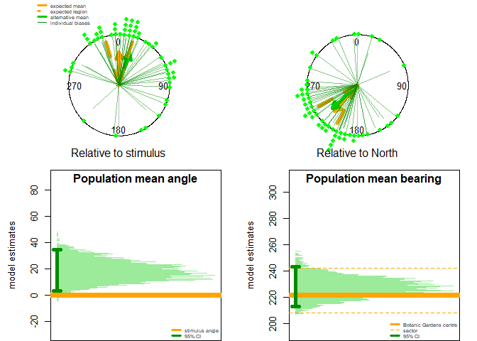

```r
par(pty = 's')
par(mfrow = c(2,2),
    mar = c(0,0,0,0))
PCfun(angles = subset(mean_vectors,
                      subset = colour %in% 'g' &
                                brightn %in% 'h' &
                                !is.na(sun_az))$mu,
      col = 'green',
      shrink = 1.5,
      plot_rho = FALSE,
      title = '\n\n\n\nRelative to stimulus')
with(dr_modlist$phototaxis,
     arrows(x0 = 0, x1 = 0,
            y0 = 0,
            y1 = A1(softplus(median(kappamu))),
            col = 'orange',
            lwd = 5,
            length = 0.1
            )
)

with(dr_modlist$no_phototaxis,
     arrows(x0 = 0,
            x1 = A1(softplus(median(kappamu)))*
              sin(median(mod_circular(b_mu0_Intercept))),
            y0 = 0,
            y1 = A1(softplus(median(kappamu)))*
              cos(median(mod_circular(b_mu0_Intercept))),
            col = 'green3',
            lwd = 5,
            length = 0.1
            )
)
arrows(x0 = c(0,0),
       x1 = sin(c(-1,1)*rope_width/2),
       y0 = c(0,0),
       y1 = cos(c(-1,1)*rope_width/2),
       col = 'orange',
       lty = 2,
       length = 0,
       lwd = 5
       )
for(id in unique(dt_photo$ID))
{
  with(dr_modlist$no_phototaxis,
       arrows(x0 = 0,
              x1 = A1(softplus(median(
                    b_kappa_Intercept +
                    get(paste0('r_ID__kappa[',id,',Intercept]'))
                                              )))*
                sin(median(mod_circular(
                  b_mu0_Intercept +
                                          get(paste0('b_mui_ID', id))
                                        ))),
              y0 = 0,
              y1 = A1(softplus(median(
                    b_kappa_Intercept +
                    get(paste0('r_ID__kappa[',id,',Intercept]')))))*
                cos(median(mod_circular(
                  b_mu0_Intercept +
                                          get(paste0('b_mui_ID', id))
                                        ))),
              col = adjustcolor('green4',alpha = 0.5),
              lwd = 0.5,
              length = 0
              )
  )
}
legend(x = 'topleft',
       legend = c('expected mean',
                  'expected region',
                  'alternative mean',
                  'individual biases'
                  ),
       col = c('orange',
               'orange',
               'green3',
               'green4'
               ),
       lty = c(1,3,1,1),
       lwd = c(3,3,3,1),
       cex = 0.5,
       bg = NA,
       bty = 'n',
       inset = c(0, 0)
       )





PCfun(angles = with(subset(mean_vectors,
                      subset = colour %in% 'g' &
                                brightn %in% 'h' &
                                !is.na(sun_az)),
                    mu + sun_az),
      col = 'green',
      shrink = 1.5,
      plot_rho = FALSE,
      title = '\n\n\n\nRelative to North')
with(as_draws_df(modlist$sunspot),
     arrows(x0 = 0,
            x1 = A1(softplus(median(kappamu)))*
              sin(garden_bearing_rad),
            y0 = 0,
            y1 = A1(softplus(median(kappamu)))*
              cos(garden_bearing_rad),
            col = 'orange',
            lwd = 5,
            length = 0.1
            )
)
with(as_draws_df(modlist$no_sunspot),
     arrows(x0 = 0,
            x1 = A1(softplus(median(kappamu)))*
              sin(median(mod_circular(b_mu0_Intercept+garden_bearing_rad                                         ))),
            y0 = 0,
            y1 = A1(softplus(median(kappamu)))*
              cos(median(mod_circular(b_mu0_Intercept+garden_bearing_rad
                                        ))),
            col = 'green3',
            lwd = 5,
            length = 0.1
            )
)
arrows(x0 = c(0,0),
       x1 = sin(rad(garden_bearing[-2])),
       y0 = c(0,0),
       y1 = cos(rad(garden_bearing[-2])),
       col = 'orange',
       lty = 2,
       length = 0,
       lwd = 5
       )
for(id in unique(dt_photo$ID))
with(as_draws_df(modlist$no_sunspot),
     arrows(x0 = 0,
            x1 = A1(softplus(median(
                    b_kappa_Intercept +
                    get(paste0('r_ID__kappa[',id,',Intercept]')))))*
              sin(median(mod_circular(
                b_mu0_Intercept+
                garden_bearing_rad +
                                          get(paste0('b_mui_ID', id))
                                        ))),
            y0 = 0,
            y1 = A1(softplus(median(
                    b_kappa_Intercept +
                    get(paste0('r_ID__kappa[',id,',Intercept]')))))*
              cos(median(mod_circular(
                b_mu0_Intercept+
                  garden_bearing_rad +
                                          get(paste0('b_mui_ID', id))
                                        ))),
            col = adjustcolor('green4',alpha = 0.5),
            lwd = 0.5,
            length = 0
            )
)

par(mar = c(0,3,0,0))

with(dr_modlist$no_phototaxis,
     {
      VertHist(data = deg(mod_circular(b_mu0_Intercept)),
         main = '\nPopulation mean angle',
         ylab = 'model estimates',
         ylim = c(-30, 90),
         col = adjustcolor('green3', alpha.f = 100/255),
         cex.axis = 0.7)
       abline(h = 0,
       col = 'orange',
       lwd = 7)
       arrows(x0 = 0, x1 = 0,
              y0 = quantile(deg(mod_circular(b_mu0_Intercept)), p = 0.025),
              y1 = quantile(deg(mod_circular(b_mu0_Intercept)), p = 1-0.025),
              col = 'green4',
              lwd = 5,
              code = 3,
              length = 0.05,
              angle = 90)
     }
       )

legend(x = 'bottomright',
       legend = c('stimulus angle',
                  '95% CI'
                  ),
       col = c('orange',
               'green4'
               ),
       lty = c(1,1),
       lwd = c(3,3),
       cex = 0.5,
       bg = NA,
       bty = 'n',
       inset = c(0, 0)
       )



gb_pos = garden_bearing[2] %% 360

with(dr_modlist$no_sunspot,
     {
      VertHist(data = deg(mod_circular(b_mu0_Intercept))  + gb_pos,
               main = '\nPopulation mean bearing',
               ylab = 'model estimates',
               ylim = c(-30, 90) + gb_pos,
               col = adjustcolor('green3', alpha.f = 100/255),
               cex.axis = 0.7)
      abline(h = garden_bearing %% 360,
             col = 'orange',
             lwd = c(1,7,1),
             lty = c(2,1,2) )
       arrows(x0 = 0, x1 = 0,
              y0 = quantile(deg(mod_circular(b_mu0_Intercept)), p = 0.025) +
                gb_pos,
              y1 = quantile(deg(mod_circular(b_mu0_Intercept)), p = 1-0.025) +
                gb_pos,
              col = 'green4',
              lwd = 5,
              code = 3,
              length = 0.05,
              angle = 90)
     }
       )

legend(x = 'bottomright',
       legend = c('Botanic Gardens centre',
                  'sector',
                  '95% CI'
                  ),
       col = c('orange',
               'orange',
               'green4'
               ),
       lty = c(1,2,1),
       lwd = c(3,0.5,3),
       cex = 0.5,
       bg = NA,
       bty = 'n',
       inset = c(0, 0)
       )
```

```r
#How much to individual dance angles vary according to kappa_mu?
with(sm_modlist$no_sunspot,
     paste0(round(deg(MardiaSD(spec_pars['kappa_mu' ,'Estimate']))), '°') )
```

```
## [1] "51°"
```

```r
#Where is the population centred?
with(dr_modlist$no_sunspot,
     {
     paste0(
       round(
       quantile(x = deg(b_mu0_Intercept),
                p = c(0,0.5,1)+c(1,0,-1)*(0.05/2) ) +
                gb_pos
                ) %% 360, # as a bearing
       '°' )
     }
)
```

```
## [1] "213°" "228°" "243°"
```

## Mean dance angles relative to the stimulus (full conditions)

Since dances do not point to a specific geographic location, it is possible that they advertise a variety of directions relative to the sun, or are not menotactic but phototactic or uniformly oriented. We can identify phototactic orientation from the angle relative to the stimulus.

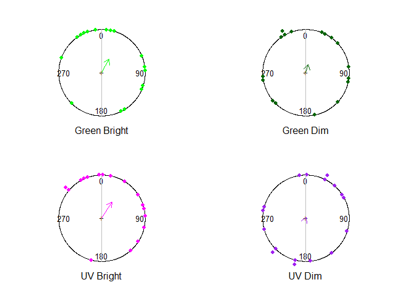

```r
par(mfrow = c(2,2), mar = c(0,0,0,0))
PCfun(angles = subset(mean_vectors_full,
                      subset = colour %in% 'g' & brightn %in% 'h')$mu,
      col = 'green',
      shrink = 1.5,
      title = 'Green Bright')
PCfun(angles = subset(mean_vectors_full,
                      subset = colour %in% 'g' & brightn %in% 'l')$mu,
      col = 'darkgreen',
      shrink = 1.5,
      title = 'Green Dim')
PCfun(angles = subset(mean_vectors_full,
                      subset = colour %in% 'u' & brightn %in% 'h')$mu,
      col = 'magenta',
      shrink = 1.5,
      title = 'UV Bright')
PCfun(angles = subset(mean_vectors_full,
                      subset = colour %in% 'u' & brightn %in% 'l')$mu,
      col = 'purple',
      shrink = 1.5,
      title = 'UV Dim')
```

While there are some dances towards or near to the stimulus for most conditions, there is a wide spread, suggesting a factor other than phototaxis sets dance directions. N.B. for the dim stimuli where the widest spread is observed, the dances are also less accurate, which may increase variation in mean dance angle.

```r
cd_sd_full = aggregate(circular(mu, units = 'degrees')~colour*brightn,
                  FUN = sd.circular,
                  data = mean_vectors_full)
cd_rho_full = aggregate(circular(mu, units = 'degrees')~colour*brightn,
                  FUN = rho.circular,
                  data = mean_vectors_full)
names(cd_sd_full)[3] = 'circular_sd'
names(cd_rho_full)[3] = 'rho'
cd_desc_full = merge(cd_sd_full, cd_rho_full)
cd_desc_full = within(cd_desc_full,
                 {sd_degrees = deg(circular_sd)})
print(cd_desc_full,digits = 2)
```

```
##   colour brightn circular_sd   rho sd_degrees
## 1      g       h         1.4 0.351         83
## 2      g       l         1.8 0.200        103
## 3      u       h         1.3 0.438         74
## 4      u       l         2.9 0.016        164
```

## Change in mean dance angle between stimuli

### Change arcs

To determine whether these dances interpret the stimuli as the sun, anti-sun or something else, we would need to check the differences in dance angle between the conditions. It is also worth considering any differences in accuracy between dances to each condition, since this would influence the variation in angular change. These can be visualised as arcs.

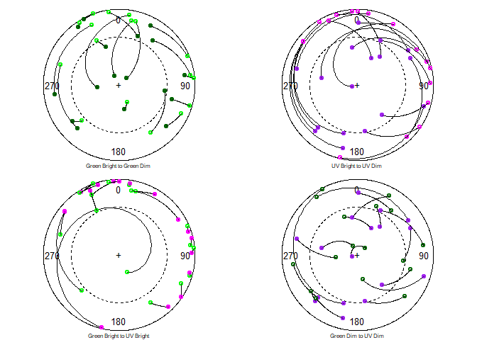

```r
par(mfrow = c(2,2), mar = c(0,0,0,0))
OpenCplot(n_sample = with(full_cd, median(run)/4) )
mtext(text = 'Green Bright to Green Dim',
      side = 1,
      line = -1,
      cex = 0.5)
#open the loop
for(ii in mean_vectors_full$ID)
{
with(subset(mean_vectors_full,
            subset = ID %in% ii),
     {
      DiffArc(a1 = mu[colour %in% 'g' &
                      brightn %in% 'h'],
              a2 = mu[colour %in% 'g' &
                        brightn %in% 'l'],
              r1 = mean_vector[colour %in% 'g' &
                              brightn %in% 'h'],
              r2 = mean_vector[colour %in% 'g' &
                                brightn %in% 'l'],
              col1 = 'green',
              col2 = 'darkgreen'
              )
     }
    )
}

OpenCplot(n_sample = with(full_cd, median(run)/4) )
mtext(text = 'UV Bright to UV Dim',
      side = 1,
      line = -1,
      cex = 0.5)
for(ii in mean_vectors_full$ID)
{
with(subset(mean_vectors_full,
            subset = ID %in% ii),
     {
      DiffArc(a1 = mu[colour %in% 'u' &
                      brightn %in% 'h'],
              a2 = mu[colour %in% 'u' &
                        brightn %in% 'l'],
              r1 = mean_vector[colour %in% 'u' &
                              brightn %in% 'h'],
              r2 = mean_vector[colour %in% 'u' &
                                brightn %in% 'l'],
              col1 = 'magenta',
              col2 = 'purple'
              )
     }
    )
}
OpenCplot(n_sample = with(full_cd, median(run)/4) )
mtext(text = 'Green Bright to UV Bright',
      side = 1,
      line = -1,
      cex = 0.5)
for(ii in mean_vectors_full$ID)
{
with(subset(mean_vectors_full,
            subset = ID %in% ii),
     {
      DiffArc(a1 = mu[colour %in% 'g' &
                      brightn %in% 'h'],
              a2 = mu[colour %in% 'u' &
                        brightn %in% 'h'],
              r1 = mean_vector[colour %in% 'g' &
                              brightn %in% 'h'],
              r2 = mean_vector[colour %in% 'u' &
                                brightn %in% 'h'],
              col1 = 'green',
              col2 = 'magenta'
              )
     }
    )
}
OpenCplot(n_sample = with(full_cd, median(run)/4) )
for(ii in mean_vectors_full$ID)
{
with(subset(mean_vectors_full,
            subset = ID %in% ii),
     {
      DiffArc(a1 = mu[colour %in% 'g' &
                      brightn %in% 'l'],
              a2 = mu[colour %in% 'u' &
                        brightn %in% 'l'],
              r1 = mean_vector[colour %in% 'g' &
                              brightn %in% 'l'],
              r2 = mean_vector[colour %in% 'u' &
                                brightn %in% 'l'],
              col1 = 'darkgreen',
              col2 = 'purple'
              )
     }
    )
}
mtext(text = 'Green Dim to UV Dim',
      side = 1,
      line = -1,
      cex = 0.5)
```

### Differences in mean angle

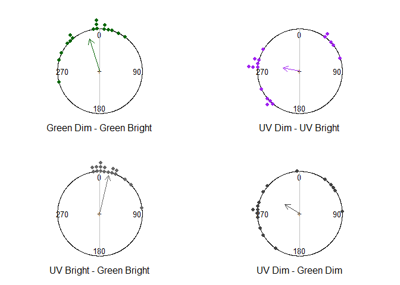

```r
mu_diff_gl = sapply(X = full_ids,
                    FUN = MuDiff,
                    dt = mean_vectors_full,
                    cl = 'g',
                    br = 'l')
mu_diff_uh = sapply(X = full_ids,
                    FUN = MuDiff,
                    dt = mean_vectors_full,
                    cl = 'u',
                    br = 'h')
mu_diff_ul = sapply(X = full_ids,
                    FUN = MuDiff,
                    dt = mean_vectors_full,
                    cl = 'u',
                    br = 'l')


#Other contrasts
mu_diff_uhl = sapply(X = full_ids,
                    FUN = MuDiff,
                    dt = mean_vectors_full,
                    cl = 'u',
                    br = 'l',
                    ref_cl = 'u',
                    ref_br = 'h')
mu_diff_gul = sapply(X = full_ids,
                    FUN = MuDiff,
                    dt = mean_vectors_full,
                    cl = 'u',
                    br = 'l',
                    ref_cl = 'g',
                    ref_br = 'h')

par(mfrow = c(2,2), mar = c(0,0,0,0))
PCfun(angles = unlist(mu_diff_gl),
      col = 'darkgreen',
      shrink = 1.5,
      title = 'Green Dim - Green Bright')
PCfun(angles = unlist(mu_diff_uhl),
      col = 'purple',
      shrink = 1.5,
      title = 'UV Dim - UV Bright')
PCfun(angles = unlist(mu_diff_uh),
      col = 'gray40',
      shrink = 1.5,
      title = 'UV Bright - Green Bright')
PCfun(angles = unlist(mu_diff_gul),
      col = 'gray25',
      shrink = 1.5,
      title = 'UV Dim - Green Dim')
```

# Estimate turn effects

## Find fit maximum likelihood turn distributions

For each change distribution, find the maximum likelihood von Mises distribution. For the UV high to UV low change, this will be a bimodal distribution.

```r
#collect all heading differences
pair_diffs_lst = lapply(X = list(#bright vs dim green
                                green_hl = mu_diff_gl,
                                #bright vs dim UV
                                uv_hl = mu_diff_uhl,
                                #bright green vs bright uv
                                uvg_h = mu_diff_uh,
                                #dim green vs bright UV
                                 uvg_l = mu_diff_gul ),
                        FUN = unlist)
#Provide appropriate data format
angle_unit = 'degrees'
angle_rot = 'clock'
#make sure they are in circular format
pair_diffs_lst = lapply(X = pair_diffs_lst,
                        FUN = circular,
                        units = angle_unit,
                        rotation = angle_rot)
```

Fit the maximum likelihood distribution for no difference between pairs, differences between pairs, and differences between pairs with two means. If angles shift in one direction between trials, the “difference” distribution should have significantly higher likelihood. If angles shift in two directions between pairs, then the “two means” distribution should be the best fit.

```r
#TODO neaten up!
#Distribution for same means
ml_same_lst = lapply(X = pair_diffs_lst,
                     FUN = mle.vonmises,
                     bias = TRUE,
                     mu = circular(x = 0,
                                   units = angle_unit,
                                   rotation = angle_rot)
)
#Distribution for different means
ml_diff_lst = lapply(X = pair_diffs_lst,
                     FUN = mle.vonmises,
                     bias = TRUE)
#Distribution for multiple different means
mod_diff_lst = lapply(X = pair_diffs_lst,
                      FUN = circ_mle,#converts circular format data to radians
                      niter = 1e4)#some stochastic variability for green stim
#Forced multiple different means
bim_diff_lst = lapply(X = pair_diffs_lst,
                      FUN = circ_mle,#converts circular format data to radians
                      exclude = c('M1','M2A', 'M2B', 'M2C'),#no uniform or unimodal
                      niter = 1e4)#some stochastic variability for green stim
```

```r
#Extract the parameters of the model with the lowest AIC
mod_diff_par = t( sapply(X = mod_diff_lst,
                      FUN = MD_extract) )
bim_diff_par = t( sapply(X = bim_diff_lst,
                      FUN = MD_extract) )

# Calculate likelihood
#calculate all in list
all_ll = mapply(FUN = LLcalc,
                ml = c(ml_same_lst, ml_diff_lst), #apply to both sets of ML estimates
                angles = pair_diffs_lst, #repeat datasets
                au = angle_unit, #important, use the same frame of reference as the original
                ar = angle_rot)

#inspect resulting parameters
mod_diff_results = do.call(rbind, c(ml_same_lst, ml_diff_lst))
#add easy to parse names
rownames(mod_diff_results) = paste( sort( #distinguish same and different mean
                          rep(x = c( 'same', 'diff'),
                              times =  length(pair_diffs_lst) ),
                          decreasing = TRUE
                          ),
                       rep(x = names(pair_diffs_lst),
                           times = 2)
                       )
#display version
rspar = mod_diff_results[,c('mu', 'kappa', 'se.mu', 'se.kappa')]
rspar = cbind(rspar, loglikelihood = all_ll)
rspar = apply(X = rspar, MARGIN = 2, FUN = unlist)
#reorder for easy comparison
rspar = rspar[c(rbind(1:4, 1:4+4)),]#put the 'diff' directly after 'same'
rspar[,3:4] = NA #overwrite columns for secondary parameters
rspar = cbind(rspar, weight1 = 1.0)
colnames(rspar) = colnames(bim_diff_par)[c(1:4, 6:5)]
all_res = rbind(data.frame(rspar),
                data.frame(bim_diff_par) )
all_res = apply(all_res, MARGIN = 2, FUN = unlist)
rn_res = rownames(all_res)#NB in R4.5 need to make a copy of rownames
rn_res[9:12] = paste('multi', rownames(bim_diff_par)) #identify bimodal rows
rownames(all_res) = rn_res #
#reorder to place unimodal and bimodal distributions of the same type together
all_res = all_res[c(1:2, 9, 3:4, 10, 5:6, 11, 7:8, 12),]

all_res = within(data = data.frame(all_res),
                 {
                   model = c('same',
                             'diff',
                             'multi')
                   dataset = c(sapply(X = names(pair_diffs_lst),
                                    FUN = rep,
                                    times = 3) )
                 }
                )
print(all_res, digits = 3)
```

```
##                   mu1 kappa1   mu2 kappa2 loglikelihood weight1  dataset model
## same green_hl    0.00  2.046    NA     NA         -19.3   1.000 green_hl  same
## diff green_hl  -17.46  2.361    NA     NA         -17.7   1.000 green_hl  diff
## multi green_hl 359.99  5.450 298.3   5.45         -16.3   0.571 green_hl multi
## same uv_hl       0.00  0.000    NA     NA         -31.2   1.000    uv_hl  same
## diff uv_hl     -78.76  0.763    NA     NA         -28.3   1.000    uv_hl  diff
## multi uv_hl    260.12  4.800  49.3  20.94         -18.2   0.706    uv_hl multi
## same uvg_h       0.00  4.464    NA     NA         -10.9   1.000    uvg_h  same
## diff uvg_h      13.11  5.827    NA     NA          -8.4   1.000    uvg_h  diff
## multi uvg_h      8.48  8.854 188.5   0.00         -13.2   0.500    uvg_h multi
## same uvg_l       0.00  0.184    NA     NA         -30.7   1.000    uvg_l  same
## diff uvg_l     -58.39  0.786    NA     NA         -28.2   1.000    uvg_l  diff
## multi uvg_l     47.27  4.979 270.7   4.98         -22.1   0.347    uvg_l multi
```

```r
#save results
write.table(x = all_res,
          file = '2Results/MLE_paired_diffs.csv',
          sep = ',',
          row.names = TRUE)
```

## Estimate confidence intervals

For each mean, simulate a distribution of mean estimates

```r
#estimate CI for unimodal von Mises models
mle_CI = with(data.frame(mod_diff_results),
              {
              mapply(FUN = CI_vM,
                     angles = pair_diffs_lst,
                     m1 = mu,
                     k1 = kappa,
                     w1 = 1,
                     alternative = 'two.sided',#not a hypothesis test (symmetrical)
                     n = 1e4)#takes ≈30s for 10 000 simulations
                }
              )
#reorder for comparison like the original models
mle_CI =  t(mle_CI)[c(rbind(1:4, 1:4+4)),]
rownames(mle_CI) = rownames(rspar)
colnames(mle_CI) = c('lower','median','upper')

#estimate CI for unimodal and bimodal von Mises models
mod_CI = with(data.frame(mod_diff_par),
              {
              mapply(FUN = CI_vM,
                     angles = pair_diffs_lst,
                     m1 = mu1,
                     k1 = kappa1,
                     m2 = mu2,
                     k2 = kappa2,
                     w1 = weight1,
                     alternative = 'two.sided',#not a hypothesis test (symmetrical)
                     n = 1e4)#takes ≈15 for 10 000 simulations
                }
              )
#estimate CI for unimodal and bimodal von Mises models
bim_CI = with(data.frame(bim_diff_par),
              {
              mapply(FUN = CI_vM,
                     angles = pair_diffs_lst,
                     m1 = mu1,
                     k1 = kappa1,
                     m2 = mu2,
                     k2 = kappa2,
                     w1 = weight1,
                     SIMPLIFY = FALSE,
                     alternative = 'two.sided',#not a hypothesis test (symmetrical)
                     n = 1e4)#takes ≈15 for 10 000 simulations
                }
              )
#collapse to printable table
mod_CI_tb = Table_vCI(mod_CI)
bim_CI_tb = Table_vCI(bim_CI)
print(mle_CI, digits = 3)
```

```
##                 lower    median   upper
## same green_hl  22.541   -0.0877  -23.06
## diff green_hl   3.617  -17.4676  -38.14
## same uv_hl     20.907 -150.3497   39.09
## diff uv_hl    -15.131  -78.4741 -140.41
## same uvg_h     13.889    0.0445  -13.56
## diff uvg_h     24.941   13.2806    1.28
## same uvg_l    160.076   -0.5201 -160.34
## diff uvg_l     -0.875  -59.0572 -120.37
```

```r
print(mod_CI_tb, digits = 3)
```

```
##          m1.lower m1.median m1.upper m2.lower m2.median m2.upper
## green_hl     17.5      9.07    0.607    -38.2     -56.4    -75.0
## uv_hl       -84.3    -99.91 -116.135     60.3      49.2     38.3
## uvg_h        23.7     13.03    2.376       NA        NA       NA
## uvg_l        68.8     46.97   25.603    -73.3     -89.1   -105.3
```

[figure not shown]

```r
par(mfrow = c(2,2), mar = c(0,0,0,0))
PCfun(angles = unlist(mu_diff_gl),
      col = 'darkgreen',
      shrink = 1.5,
      title = 'Green Dim - Green Bright')
PlotCI_vM(mle_CI['diff green_hl',],
          col = 'darkgreen',
          radius = 1+0.3)

plot.circular(x = circular(unlist(mu_diff_uhl),
                           units = angle_unit,
                           rot = angle_rot
                           ),
              col = 'purple',
              stack = TRUE,
              sep = 0.1,
              bins = 355/5,
              units = angle_unit,
              rotation = angle_rot,
              zero = pi/2,
              shrink = 1.5)
mtext(text = 'UV Dim - Green Bright',
      side = 1,
      line = -2)
lines(x = c(0,0),
      y = c(-1,1),
      col = 'gray')
PlotMV_circMLE(mod_par = mod_diff_par['uv_hl',],
               col1 = 'purple')
PlotCI_vM(mod_CI_tb['uv_hl',],
          col = 'purple',
          radius = 1+0.3)

PCfun(angles = unlist(mu_diff_uh),
      col = 'gray40',
      shrink = 1.5,
      title = 'UV Bright - Green Bright')
PlotCI_vM(mod_CI_tb['uvg_h',],
          col = 'gray40',
          radius = 1+0.3)
#according to model comparison, bim_diff_par['uvg_h',] is sometimes better
#but is not truly bimodal, kappa2 = 0

plot.circular(x = circular(unlist(mu_diff_gul),
                           units = angle_unit,
                           rot = angle_rot
                           ),
              col = 'gray25',
              stack = TRUE,
              sep = 0.1,
              bins = 355/5,
              units = angle_unit,
              rotation = angle_rot,
              zero = pi/2,
              shrink = 1.5)
mtext(text = 'UV Dim - Green Dim',
      side = 1,
      line = -2)
lines(x = c(0,0),
      y = c(-1,1),
      col = 'gray')
PlotMV_circMLE(mod_par = mod_diff_par['uvg_l',],
               col1 = 'gray25')
PlotCI_vM(mod_CI_tb['uvg_l',],
          col = 'gray25',
          radius = 1+0.3)
```

Here we see that the confidence interval for the difference between the green conditions overlaps with 0°, and the one for the two bright conditions almost does (the one sided CI does, but looks odd due it its asymmetry). To confirm whether these models better explain the data than the null hypothesis of the same mean for each condition (no difference), we can perform a likelihood-ratio test.

## Likelihood ratio tests

For each condition, compare the models for same mean, different mean and multiple means. First perform all tests separately, then collect them together and finally adjust for multiple tests before reporting.

```r
mod_details= lapply(X = names(pair_diffs_lst),
                     FUN = CollectDetails,
                     ll = all_res,
                     bimod = TRUE)
names(mod_details) = names(pair_diffs_lst)


#save details
save(x = mod_details,
          file = '2Results/MLEdetails_paired_diffs.RData')

#set up tests for hypotheses
lr_tests = c('pairs_diff_zero', #is the turn different from zero?
             'pairs_multi_diff', #is the turn in one or two directions?
             'pairs_multi_zero' #are the two directions different from zero?
             )#multiple tests

#Perform collect likelihood ratio tests for each hypothesis
all_lr_results_lst = lapply(X =mod_details,
                           FUN = LR_calc_lst,
                           tst = lr_tests)
all_lr_results = do.call(what = rbind,
                          args = all_lr_results_lst
                          )
all_lr_results = within(data.frame(all_lr_results),
                        {
                            comparison = c( sapply(X = names(mod_details),
                            FUN = rep,
                            times = length(lr_tests)
                            ) )
                            test = rep(lr_tests,
                                      times = length(names(mod_details))
                            )
                        }
                      )

#add labels to interpret each test according to p value and sign of comparison
all_lr_results = within(all_lr_results,
                     {
                       result = mapply(tst = lr_tests,
                                       d0 = unlist(dev0),
                                       d1 = unlist(dev1),
                                       pa = p_adjusted,
                                       FUN = H1label
                       )
                     }
)
print_lr_results = all_lr_results
print_lr_results = within(print_lr_results,
                          {
                            rm(dev0,dev1, p)
                          test = sub(sub(sub(test,
                                     pattern = '_',
                                     replacement = ' '),
                                     pattern = '_',
                                     replacement = ' '),
                                     pattern = 'pairs ',
                                     replacement = '')
                          mu1 = round(all_res$mu1, 1)
                          }
                          )
print_lr_results = within(print_lr_results,
                           {mu2 = round(all_res$mu2, 1)}
                          )
rownames(print_lr_results) = with(print_lr_results, paste(comparison, test))#better to keep them for the html
#Round numeric columns
num_col = sapply(X = print_lr_results,
                 FUN = is.numeric)
print_lr_results[,num_col] = apply(X = print_lr_results[,num_col],
                                   MARGIN = 2,
                                   FUN = round,
                                   digits = 3)
#Print the results
print(print_lr_results[,-6],
      digits = 3)
```

```
##                     d.f. chi_squared p_adjusted       test comparison   mu1
## green_hl diff zero     1        3.31      0.206  diff zero   green_hl   0.0
## green_hl multi diff    3        2.78      0.427 multi diff   green_hl -17.5
## green_hl multi zero    4        6.09      0.289 multi zero   green_hl 360.0
## uv_hl diff zero        1        5.82      0.016  diff zero      uv_hl   0.0
## uv_hl multi diff       3       20.21      0.000 multi diff      uv_hl -78.8
## uv_hl multi zero       4       26.03      0.000 multi zero      uv_hl 260.1
## uvg_h diff zero        1        5.04      0.037  diff zero      uvg_h   0.0
## uvg_h multi diff       3        9.56      0.037 multi diff      uvg_h  13.1
## uvg_h multi zero       4        4.52      0.340 multi zero      uvg_h   8.5
## uvg_l diff zero        1        4.98      0.026  diff zero      uvg_l   0.0
## uvg_l multi diff       3       12.27      0.010 multi diff      uvg_l -58.4
## uvg_l multi zero       4       17.26      0.005 multi zero      uvg_l  47.3
##                       mu2
## green_hl diff zero     NA
## green_hl multi diff    NA
## green_hl multi zero 298.3
## uv_hl diff zero        NA
## uv_hl multi diff       NA
## uv_hl multi zero     49.3
## uvg_h diff zero        NA
## uvg_h multi diff       NA
## uvg_h multi zero    188.5
## uvg_l diff zero        NA
## uvg_l multi diff       NA
## uvg_l multi zero    270.7
```

```r
#save results
write.table(x = print_lr_results,
          file = '2Results/LRT_paired_diffs.csv',
          sep = ',',
          row.names = TRUE)
```

These tests confirm, that there is no significant difference between the two green conditions, a marginally-significant 13° left turn between the bright conditions, and significant bimodal differences between the two UV conditions and the two dim conditions, driven by left and right turns for the dim UV condition.

## Bayes-factor equivalent

```r
# Initialize an empty list to store row segments
table_rows = list()

# Loop through each dataset in your list
for (dts in names(pair_diffs_lst)) {

  mdt_metrics = BFDetails(all_res,
                               dts = dts,
                               bimod = TRUE,
                               n_obs = length(pair_diffs_lst[[dts]]))

  # Define the 3 tests to run per dataset to match your layout
  test_types = c("pairs_diff_zero",
                 "pairs_multi_diff",
                 "pairs_multi_zero")
  display_names = c("diff zero",
                    "multi diff",
                    "multi zero")
  dfs = c(1, 3, 4) # structural degrees of freedom for the tests

  for (i in 1:length(test_types)) {

    # Calculate Bayesian metrics for this specific test
    bf_out = BF_calc(tst = test_types[i],
                     mdt = mdt_metrics)
    label_out = BFlabel(test_types[i],
                        bf_out$Bayes_factor_1.0 )

    # Construct unique row name (e.g., "green_hl diff zero")
    row_id = paste(dts, display_names[i])

    # Assemble the individual row without mu1 and mu2 columns
    table_rows[[ row_id]] = with(bf_out,
                                {
          data.frame(
            df          = dfs[i],
            delta_BIC   = round(delta_bic, 3),
            Bayes_factor_1.0         = round(Bayes_factor_1.0 , 4),
            test        = display_names[i],
            comparison  = dts,
            result      = label_out,
            stringsAsFactors = FALSE
            )
                                }
    )
  }
}

# Bind all collected rows into a unified final master table
bf_summary_table = do.call(rbind, table_rows)
#Print the results
print(bf_summary_table,
      digits = 3)
```

```
##                     df delta_BIC Bayes_factor_1.0       test comparison
## green_hl diff zero   1     0.479         1.27e+00  diff zero   green_hl
## green_hl multi diff  3    -5.723         5.72e-02 multi diff   green_hl
## green_hl multi zero  4    -5.244         7.26e-02 multi zero   green_hl
## uv_hl diff zero      1     2.982         4.44e+00  diff zero      uv_hl
## uv_hl multi diff     3    11.711         3.49e+02 multi diff      uv_hl
## uv_hl multi zero     4    14.693         1.55e+03 multi zero      uv_hl
## uvg_h diff zero      1     2.210         3.02e+00  diff zero      uvg_h
## uvg_h multi diff     3   -18.065         1.00e-04 multi diff      uvg_h
## uvg_h multi zero     4   -15.855         4.00e-04 multi zero      uvg_h
## uvg_l diff zero      1     2.150         2.93e+00  diff zero      uvg_l
## uvg_l multi diff     3     3.774         6.60e+00 multi diff      uvg_l
## uvg_l multi zero     4     5.925         1.93e+01 multi zero      uvg_l
##                                        result
## green_hl diff zero  Anecdotal evidence for H1
## green_hl multi diff    Strong evidence for H0
## green_hl multi zero    Strong evidence for H0
## uv_hl diff zero     *Moderate evidence for H1
## uv_hl multi diff     Decisive evidence for H1
## uv_hl multi zero     Decisive evidence for H1
## uvg_h diff zero     *Moderate evidence for H1
## uvg_h multi diff     Decisive evidence for H0
## uvg_h multi zero     Decisive evidence for H0
## uvg_l diff zero     Anecdotal evidence for H1
## uvg_l multi diff    *Moderate evidence for H1
## uvg_l multi zero      *Strong evidence for H1
```

```r
#save results
write.table(x = bf_summary_table,
          file = '2Results/BF_paired_diffs.csv',
          sep = ',',
          row.names = TRUE)
```

# Are the two means for UV dim equally likely

```r
wt_uv_hl = all_res['multi uv_hl', 'weight1']
est_no_m1 = round(length(full_ids)*wt_uv_hl)
binom.test(x = est_no_m1,
           n = length(full_ids),
           p = 0.5,
           alternative = 'two.sided')
```

```
##
##  Exact binomial test
##
## data:  est_no_m1 and length(full_ids)
## number of successes = 13, number of trials = 19, p-value = 0.1671
## alternative hypothesis: true probability of success is not equal to 0.5
## 95 percent confidence interval:
##  0.4344984 0.8742394
## sample estimates:
## probability of success
##              0.6842105
```

```r
#CI for relative weight
#circMLE default from Hessians
with(mod_diff_lst,
     ci_circmle(circmle = uv_hl,
                model = uv_hl$bestmodel)
    )
```

```
##   Parameter    MLE    SE              CI
## 1        q1   4.54  0.14   4.266 - 4.814
## 2        k1  4.798 1.824   1.223 - 8.373
## 3        q2   0.86 0.099   0.666 - 1.054
## 4        k2 20.941 13.08 -4.697 - 46.579
## 5    lambda  0.706 0.111   0.489 - 0.923
```

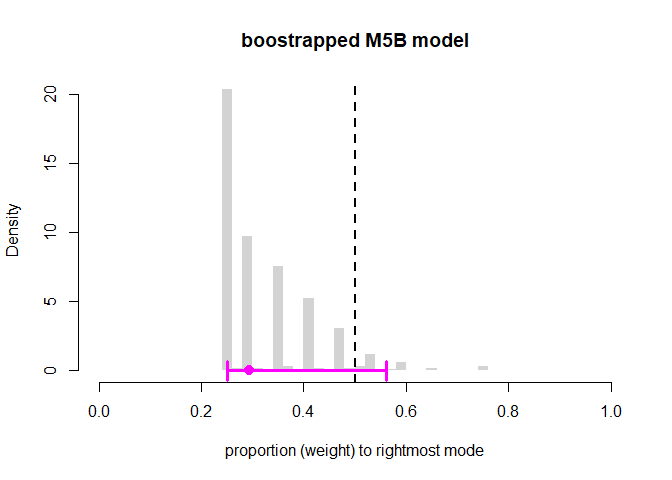

```r
#we can also bootstrap it
lambda_uhl = BootBimod(angles = unlist(mu_diff_uhl),
                       model = with(mod_diff_lst, uv_hl$bestmodel),
                       speedup_parallel = TRUE,
                       calc_q = FALSE,
                       n = 1e3) #save all for plotting
q_uhl = quantile(lambda_uhl,
         probs = c(0,0.5,1)+c(1,0,-1)*((1-0.95)/2)
        )
hist(lambda_uhl,
     breaks = 20,
     xlim = c(0,1),
     border = NA,
     probability = TRUE,
     main = 'boostrapped M5B model',
     xlab = 'proportion (weight) to rightmost mode'
     )
abline(v = 0.5,
       lty = 2,
       col = 'black',
       lwd = 2)
arrows(x0 = q_uhl[1],
       x1 = q_uhl[3],
       y0 = 0,
       y1 = 0,
       length = 0.1,
       angle = 90,
       code = 3,
       lwd = 3,
       col = 'magenta'
       )
points(x = q_uhl[2],
       y = 0,
       pch = 20,
       col = 'magenta',
       cex = 2)
```

```r
print(q_uhl,
      digits = 3)
```

```
##  2.5%   50% 97.5%
## 0.250 0.294 0.560
```

## Angle between the means and 0°

```r
abs_ang_uhl = abs(unlist(mu_diff_uhl))
dt_ang_uhl = data.frame(betaresp = abs_ang_uhl/180)
beta_ang_uhl = brm(bf(betaresp~1,
                      phi~1),
                   data = dt_ang_uhl,
                   family = Beta(link = 'logit',
                                 link_phi = 'log'),
                   backend = 'cmdstanr')
```

[output not shown]

[output cut: 43 more lines]

[output not shown]

```r
beta_ang_uhl_null = brm(bf(betaresp~0,
                      phi~1),
                   data = dt_ang_uhl,
                   family = Beta(link = 'logit',
                                 link_phi = 'log'),
                   backend = 'cmdstanr')
```

[output not shown]

[output cut: 43 more lines]

[output not shown]

```r
summary(beta_ang_uhl)
```

```
##  Family: beta
##   Links: mu = logit; phi = log
## Formula: betaresp ~ 1
##          phi ~ 1
##    Data: dt_ang_uhl (Number of observations: 17)
##   Draws: 4 chains, each with iter = 2000; warmup = 1000; thin = 1;
##          total post-warmup draws = 4000
##
## Regression Coefficients:
##               Estimate Est.Error l-95% CI u-95% CI Rhat Bulk_ESS Tail_ESS
## Intercept        -0.09      0.19    -0.46     0.28 1.00     2748     1992
## phi_Intercept     1.79      0.33     1.11     2.40 1.00     2788     2633
##
## Draws were sampled using sample(hmc). For each parameter, Bulk_ESS
## and Tail_ESS are effective sample size measures, and Rhat is the potential
## scale reduction factor on split chains (at convergence, Rhat = 1).
```

```r
loo_beta_uhl = loo(beta_ang_uhl)
loo_beta_uhl_null = loo(beta_ang_uhl_null)
loo_compare(loo_beta_uhl, loo_beta_uhl_null)
```

```
##                   elpd_diff se_diff
## beta_ang_uhl_null  0.0       0.0
## beta_ang_uhl      -0.9       0.6
```

```r
#the distribution is concave (phi>2) in 99.9% of draws
mean(
  exp(
    as_draws_df(beta_ang_uhl_null,
                dpar = 'Intercept_phi')$Intercept_phi
    )<2) *100
```

```
## [1] 0.15
```

```r
#estimate mean angular difference
emm_ang_uhl = emmeans(beta_ang_uhl,
                      specs = '1')
print(
  summary(emm_ang_uhl,
              type = 'response')[2:4]*180,
  digits = 1)
```

```
##   response lower.HPD upper.HPD
## 1       86        69       102
```